# TFM - Anexo II.- Fase de Modelización

Mª Antonia Mira Paz

9/7/2021

# 1 Objetivos de esta fase.

- En esta fase encontraremos el **mejor modelo** para predecir **si** un **atentado** se llevará a cabo con **éxito o fracaso**, mediante técnicas de **Machine Learning**. Para ello, utilizaré **algoritmos de clasificación** tanto de la **librería** **Caret**, como de la librería **H2O**. Determinando el nivel de precisión de cada modelo y analizando los resultados del mismo.
- Analizaré las **variables más importantes** de dicho modelo. Con el fin de que esta información pueda utilizarse después.

# 2 Lectura de los datos.

Tener en cuenta que en esta fase utilizaré los **dataset** del **AnexoI**, **depurados y preparados**, para poder utilizarse con diferentes algortimos de Machine Learning.

Recordemos que **analizaré** la **bondad del ajuste** de cada **modelo**, diferenciando **dos escenarios**.

- **Escenario 1**: Dataset **con** las variables **numéricas**: **‘nkill’**, **‘nkillter’**, **‘nwound’**, **‘nwoundte’**, **‘fe_npercap’**, **‘fe_imonth’** y **‘fe_iday’**.
- **Escenario 2**: Dataset con **las** variables numéricas **recategorizadas**: **‘fe_fe_nperpcap_tram’** , **‘fe_fe_nkill_tram’**, **‘fe_fe_nkillter_tram’**, **‘fe_fe_nwound_tram’**, **‘fe_fe_nwoundte_tram’**, **‘fe_quincena’** y **‘fe_trimestre’**.

Empezaré por establecer nuestro directorio de trabajo, cargar las funciones y paquetes que vamos a utilizar.

```r
#Fijo nuestro directorio de trabajo
setwd('./')

#Cargo las funciones necesarias
source("./Funciones_R.R")
```

Cargo las librerias necesarias

```r
suppressPackageStartupMessages({
  library(data.table)
  library(dplyr)
  library(caret)
  library(scales)
  library(ggplot2)
  library(gridExtra)
  library(stringi)
  library(stringr)
  library(dataPreparation)
  library(knitr)
  library(kableExtra)
  library(ggpubr)
  library(tictoc)
  library(ggeasy)
  library(lubridate)
  library(inspectdf)
  library(fastDummies)
  library(e1071)
  library(MLmetrics)
  library(ranger)
  library(caTools)
  library(h2o)
  library(questionr)
  library(corrplot)
  library(funModeling)
  library(glmnet)

  library(tidyr)
})
```

A continuación, cargo los datos de ambos escenarios

```r
#Cargo los datos del primer escenario (variables continuas)
datMod_es1 <- as.data.frame(fread("datos_escenario1_atentados.csv"), nThread = 2)

#Cargo los datos del segundo escenario (variables recategorizadas)
datMod_es2 <- as.data.frame(fread("datos_escenario2_atentados.csv"), nThread = 2)
```

Los dataset contienen **191464 registros** y **21 variables**.

```r
#Compruebo el tipo de las variables del dataset del escanario 1 por si hubiera algún error
str(datMod_es1)
```

```
## 'data.frame':    191464 obs. of  21 variables:
##  $ iyear                 : int  1970 1970 1970 1970 1970 1970 1970 1970 1970 1970 ...
##  $ country               : int  58 130 160 78 101 217 218 217 217 217 ...
##  $ region                : int  2 1 5 8 4 1 3 1 1 1 ...
##  $ natlty1               : int  58 21 217 217 217 217 218 217 217 217 ...
##  $ nkill                 : int  1 0 1 0 0 0 0 0 0 0 ...
##  $ nkillter              : int  0 0 0 0 0 0 0 0 0 0 ...
##  $ nwound                : num  0 0 0 0 0 0 0 0 0 0 ...
##  $ nwoundte              : int  0 0 0 0 0 0 0 0 0 0 ...
##  $ fe_nperpcap           : num  0 2 3 0 3 2 4 1 1 1 ...
##  $ fe_imonth             : int  7 11 1 1 1 1 1 1 1 1 ...
##  $ fe_iday               : int  2 7 20 23 22 1 2 2 2 3 ...
##  $ fe_distancia          : num  72.3 101 121.6 44.8 134.7 ...
##  $ fe_fe_vicinity        : int  0 0 0 0 0 0 0 0 0 0 ...
##  $ fe_INT_LOG            : int  86852 86852 97036 97036 97036 97036 86852 97036 86852 86852 ...
##  $ fe_INT_IDEO           : int  69740 24556 97168 97168 97168 97168 69740 97168 69740 69740 ...
##  $ fe_INT_ANY            : int  63859 39588 39588 39588 39588 88017 63859 88017 63859 63859 ...
##  $ fe_fe_attacktype1     : int  20338 12260 20338 98394 11026 46542 20338 98394 11026 11026 ...
##  $ fe_fe_nperps_tram     : int  50420 50420 17587 17587 16598 97575 9284 97575 17587 17587 ...
##  $ fe_fe_targtype1_retram: int  49015 39536 39536 39536 39536 27564 27564 39536 31115 22479 ...
##  $ fe_fe_weaptype1_retram: int  70758 70758 70758 103470 12310 70758 70758 103470 12310 12310 ...
##  $ varObj                : chr  "Yes" "Yes" "Yes" "Yes" ...
```

```r
#Compruebo el tipo de las variables del dataset del escanario 2 por si hubiera algún error
str(datMod_es2)
```

```
## 'data.frame':    191464 obs. of  21 variables:
##  $ iyear                 : int  1970 1970 1970 1970 1970 1970 1970 1970 1970 1970 ...
##  $ country               : int  58 130 160 78 101 217 218 217 217 217 ...
##  $ region                : int  2 1 5 8 4 1 3 1 1 1 ...
##  $ natlty1               : int  58 21 217 217 217 217 218 217 217 217 ...
##  $ fe_distancia          : num  72.3 101 121.6 44.8 134.7 ...
##  $ fe_fe_vicinity        : int  0 0 0 0 0 0 0 0 0 0 ...
##  $ fe_INT_LOG            : int  86852 86852 97036 97036 97036 97036 86852 97036 86852 86852 ...
##  $ fe_INT_IDEO           : int  69740 24556 97168 97168 97168 97168 69740 97168 69740 69740 ...
##  $ fe_INT_ANY            : int  63859 39588 39588 39588 39588 88017 63859 88017 63859 63859 ...
##  $ fe_fe_attacktype1     : int  20338 12260 20338 98394 11026 46542 20338 98394 11026 11026 ...
##  $ fe_fe_nperps_tram     : int  50420 50420 17587 17587 16598 97575 9284 97575 17587 17587 ...
##  $ fe_fe_nperpcap_tram   : int  141352 11729 17245 141352 17245 11729 17245 21138 21138 21138 ...
##  $ fe_fe_nkill_tram      : int  40490 97386 40490 97386 97386 97386 97386 97386 97386 97386 ...
##  $ fe_fe_nkillter_tram   : int  164518 164518 164518 164518 164518 164518 164518 164518 164518 164518 ...
##  $ fe_fe_nwound_tram     : int  117611 117611 117611 117611 117611 117611 117611 117611 117611 117611 ...
##  $ fe_fe_nwoundte_tram   : int  184477 184477 184477 184477 184477 184477 184477 184477 184477 184477 ...
##  $ fe_fe_targtype1_retram: int  49015 39536 39536 39536 39536 27564 27564 39536 31115 22479 ...
##  $ fe_fe_weaptype1_retram: int  70758 70758 70758 103470 12310 70758 70758 103470 12310 12310 ...
##  $ fe_fe_trimestre       : int  48676 46281 46483 46483 46483 46483 46483 46483 46483 46483 ...
##  $ fe_fe_quincena        : int  96034 96034 95430 95430 95430 96034 96034 96034 96034 96034 ...
##  $ varObj                : chr  "Yes" "Yes" "Yes" "Yes" ...
```

Los dataset contienen **191464 registros** y **21 variables**.

Observo que al leer los archivos en R, se han modidificado en ambos dataset el tipo de la variable objetivo, ahora aparacen como tipo carácter, por lo que debemos cambiarlos de nuevo, a tipo factor.

```r
#Transformo la clase de la variable objetivo en el dataset del primer escenario
datMod_es1$varObj <- as.factor(datMod_es1$varObj)

#Transformo la clase de la variable objetivo en el dataset del segundo escenario
datMod_es2$varObj <- as.factor(datMod_es2$varObj)
```

Compruebo de nuevo los tipos de las variables de los archivos

```r
#str(datMod_es1)
#str(datMod_es2)
```

Ahora la **variable objetivo** está en el **tipo correcto**

# 3 Train & Test.

Voy a crear los **subconjuntos** de datos, tanto para **entrenar** el modelo, como para **validarlo**.

## 3.1 Train & Test para el escenario 1.

Formo la partición **Train/Test** para el conjunto de datos del **escenario 1**.

```r
#Split out validation dataset
#Create a list of 80% of the rows in the original dataset we can use for trainig
set.seed(7)
validationIndex <- createDataPartition (datMod_es1$varObj, p=0.80, list = FALSE)
#use the remaining 80% of data to training and testing
train_es1 <- datMod_es1[validationIndex,]
#select 20% of the data for validation
test_es1 <- datMod_es1[-validationIndex,]
```

## 3.2 Train & Test para el escenario 2.

Creo la partición **Train/Test** para el conjunto de datos del **escenario 2**.

```r
#Split out validation dataset
#Create a list of 80% of the rows in the original dataset we can use for trainig
set.seed(7)
validationIndex <- createDataPartition (datMod_es2$varObj, p=0.80, list = FALSE)
#use the remaining 80% of data to training and testing
train_es2 <- datMod_es2[validationIndex,]
#select 20% of the data for validation
test_es2 <- datMod_es2[-validationIndex,]
```

# 4 Libreria Caret.

Empezaré por los **algoritmos de clasificación** más **clásicos** que nos proporciona la **librería Caret**.

## 4.1 Algoritmo ‘GLM’

En primer lugar, voy a utilizar el algoritmo ‘GLM’, es uno de los **algoritmos de Machine Learning más simples** y **más utilizados** para la **clasificación de dos clases**.

- **Ventajas**:
  - Es **fácil de implementar e interpretar**.
  - Se puede usar **como** línea de **base** para cualquier problema de clasificación binaria.
  - Un **algoritmo** de **clasificación bastante bueno**, **siempre que** espere que sus **características** sean **aproximadamente lineales**.
  - Da **estimaciones** de qué **variables** son **importantes** en la clasificación.
- **Incovenientes**:
  - Existencia de datos no lineales, se debe hacer un **buen Feature Engineering** para poder **convertir** fácilmente la mayoría de las **características no lineales** en **características lineales**.
  - Con los **valores muy anómalos**, este algoritmo puede **abortar su ejecución**.
  - Sufre de **multicolinealidad**.
  - Necesario **estandarizar** los datos.

### 4.1.1 Algoritmo ‘GLM’ para el escenario 1.

```r
#Creo la función de control con validación cruzada y así evitar el Overfiting
trainControl <- trainControl(method = "cv", #Evitamos el overfitting
                             number = 5,
                             classProbs = TRUE, #Para que calcule las probabilidades de clase en cada muestra.
                             summaryFunction = twoClassSummary,
                             returnResamp = "all"
)
#Fijo la semilla
set.seed(7)
#Entreno el modelo glm para el escenario 1 con los datos de train
modelo1_glm_es1 <- train(
            varObj ~ .,
            data = train_es1,
            method = 'glm',
            metric = 'ROC',
            preProc = c("center", "scale"), #Estandarizo los datos
            family = binomial,
            trControl = trainControl
)
```

- **Resultados del modelo.**

```r
#Imprimimos las métricas del modelo en Train
print(modelo1_glm_es1, positive = "Yes")
```

```
## Generalized Linear Model
##
## 153172 samples
##     20 predictor
##      2 classes: 'No', 'Yes'
##
## Pre-processing: centered (20), scaled (20)
## Resampling: Cross-Validated (5 fold)
## Summary of sample sizes: 122538, 122537, 122538, 122538, 122537
## Resampling results:
##
##   ROC        Sens         Spec
##   0.7934486  0.004499434  0.9984319
```

El modelo tiene una estimación del error en train del **79% (ROC)**.

- **Estimación de los coeficientes del modelo.**

```r
summary(modelo1_glm_es1)
```

```
##
## Call:
## NULL
##
## Deviance Residuals:
##     Min       1Q   Median       3Q      Max
## -8.4904   0.1525   0.3882   0.5495   8.4904
##
## Coefficients:
##                         Estimate Std. Error z value Pr(>|z|)
## (Intercept)             3.451743   0.025363 136.096  < 2e-16 ***
## iyear                  -0.534417   0.012817 -41.698  < 2e-16 ***
## country                -0.146373   0.009921 -14.753  < 2e-16 ***
## region                 -0.119932   0.015676  -7.651 2.00e-14 ***
## natlty1                 0.057635   0.010586   5.445 5.19e-08 ***
## nkill                   7.506402   0.140267  53.515  < 2e-16 ***
## nkillter               -2.789149   0.052458 -53.169  < 2e-16 ***
## nwound                  7.871143   0.234120  33.620  < 2e-16 ***
## nwoundte               -0.340009   0.021627 -15.722  < 2e-16 ***
## fe_nperpcap            -0.008783   0.011254  -0.780  0.43514
## fe_imonth              -0.022126   0.008419  -2.628  0.00859 **
## fe_iday                -0.036086   0.008432  -4.280 1.87e-05 ***
## fe_distancia           -0.068388   0.013412  -5.099 3.42e-07 ***
## fe_fe_vicinity          0.013114   0.008506   1.542  0.12314
## fe_INT_LOG              0.079387   0.009858   8.053 8.08e-16 ***
## fe_INT_IDEO            -0.204252   0.014607 -13.983  < 2e-16 ***
## fe_INT_ANY              0.126774   0.014285   8.874  < 2e-16 ***
## fe_fe_attacktype1       0.351913   0.013204  26.653  < 2e-16 ***
## fe_fe_nperps_tram       0.165668   0.010111  16.386  < 2e-16 ***
## fe_fe_targtype1_retram  0.064192   0.008708   7.372 1.68e-13 ***
## fe_fe_weaptype1_retram -0.671176   0.016248 -41.308  < 2e-16 ***
## ---
## Signif. codes:  0 '***' 0.001 '**' 0.01 '*' 0.05 '.' 0.1 ' ' 1
##
## (Dispersion parameter for binomial family taken to be 1)
##
##     Null deviance: 108174  on 153171  degrees of freedom
## Residual deviance:  94043  on 153151  degrees of freedom
## AIC: 94085
##
## Number of Fisher Scoring iterations: 9
```

Podemos **ver** los **parámetros** que son **significativamente distintos** de **cero**. Es decir, la **aportación** de variabilidad de **cada variable al modelo** predictivo y así hacernos una idea inicial de las variables más o menos influyentes en el modelo.

- **Evaluación del modelo**

Evaluamos el modelo teniendo en cuenta los datos de test.

```r
#Fijo la semilla
set.seed(7)
#Genero el modelo con los datos de test, escenario 1.
modelo1_glm_es1_test <- train(
            varObj ~ .,
            data = test_es1,
            method = 'glm',
            metric = 'ROC',
            preProc = c("center", "scale"), #Estandarizo los datos
            trControl = trainControl #Utilizo el mismo trainControl que el anterior
)
```

```r
set.seed(7)
#Imprimimos las métricas del modelo en Test
print(modelo1_glm_es1_test, positive = "Yes")
```

```
## Generalized Linear Model
##
## 38292 samples
##    20 predictor
##     2 classes: 'No', 'Yes'
##
## Pre-processing: centered (20), scaled (20)
## Resampling: Cross-Validated (5 fold)
## Summary of sample sizes: 30634, 30633, 30633, 30634, 30634
## Resampling results:
##
##   ROC        Sens         Spec
##   0.7925879  0.002769232  0.9982037
```

Vemos como la curva **ROC**, se mantiene en **test** en un **79%** (79% en train), lo que me hace pensar que **no** hay **overtting**.

- **Matriz de confusión.**

```r
set.seed(7)
#Calculo las prediciones para test
prediciones <- predict(modelo1_glm_es1_test, newdata = test_es1)
#Obtengo la matriz de confusión y mérticas del modelo en test
confusionMatrix(test_es1$varObj, prediciones, positive = "Yes")
```

```
## Confusion Matrix and Statistics
##
##           Reference
## Prediction    No   Yes
##        No     13  4320
##        Yes    58 33901
##
##                Accuracy : 0.8857
##                  95% CI : (0.8824, 0.8888)
##     No Information Rate : 0.9981
##     P-Value [Acc > NIR] : 1
##
##                   Kappa : 0.0023
##
##  Mcnemar's Test P-Value : <2e-16
##
##             Sensitivity : 0.8870
##             Specificity : 0.1831
##          Pos Pred Value : 0.9983
##          Neg Pred Value : 0.0030
##              Prevalence : 0.9981
##          Detection Rate : 0.8853
##    Detection Prevalence : 0.8868
##       Balanced Accuracy : 0.5350
##
##        'Positive' Class : Yes
##
```

Dado que nuestro **datos** están **desbalanceados**, debemos tener **en cuenta** para medir la efectividad de nuestro modelo, no sólo, la **capacidad y precisión**, que tiene de **clasificar correctamente** los **casos exitosos**, si no también, la capacidad y precisión, que tiene de clasificar los **casos no exitosos**. Por que si sólo tenemos encuenta la clase mayoritaria, tendremos una falsa sensación de que el modelo funciona bien.

Por lo que, tendremos en cuenta las **métricas** de **‘Precisión’** y **‘Recall’** **por** cada **clase**.

Si observamos la matriz de confusión, podemos ver que de los 71 atentados que en realidad no son exitosos, el modelo es capaz de reconocer a 13 (hay 58 falsos positivos), de 38221 que son en realidad atentados exitosos, el modelo reconoce a 33901 (hay 4320 falsos negativos).

En cuanto a la **‘Precisión’** del modelo, es decir, cuanto de confiable es el modelo en clasificar correctamente, tenemos que en lo **casos exitosos** el modelo tiene una precisión muy alta, **99.83%**. **Y** nivel de precisión en los casos **no exitosos**, es del **0.3%!**! Una precisión muy baja.

Este modelo **clasifica muy bien** los **casos exitosos**, pero no tanto los casos no exitosos, por lo que **debemos mejorar** el modelo, intentado aumentar la **capacidad** **y** la **precisión** de reconocer los **casos no exitosos**.

- **Importancia de cada variable.**

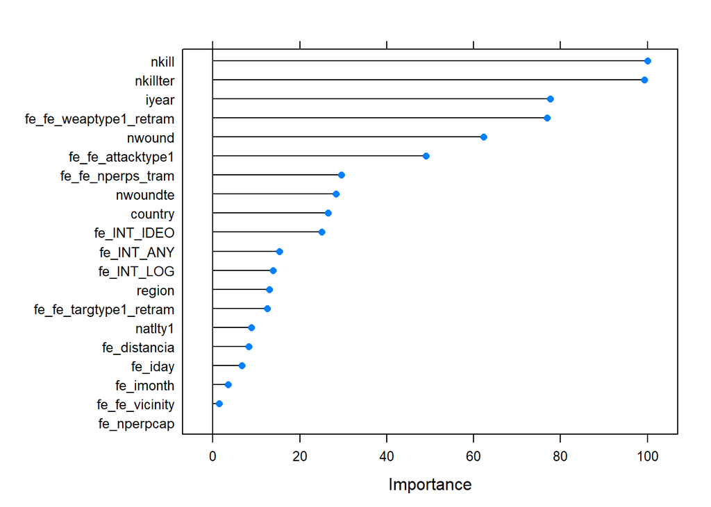

```r
#Gráfico de las variables más importantes para el modelo
plot(varImp(modelo1_glm_es1))
```

Podemos decir que las variable que **aporta mayor información** al modelo con diferencia son, **‘nkill’** y **‘nkillter’**, seguidas de, **‘iyear’**, **‘nwound’** y **‘weaptype1’**. El resto de variables por debajo del 50%.

### 4.1.2 Algoritmo ‘GLM’ para el escenario 2.

Probaré con el algoritmo anterior, para el **grupo de datos** que contiene, algunas de las variables especificadas anteriormente, en **versión categoríca**. Y así poder ver si mejora el modelo en valor predictivo.

```r
#Creo la función de control con validación cruzada y así evitar el Overfiting
trainControl <- trainControl(method = "cv", #Evitamos el overfitting
                             number = 5,
                             classProbs = TRUE,
                             summaryFunction = twoClassSummary,
                             returnResamp = "all"
)
#Fijo la semilla
set.seed(7)
#Entreno el modelo glm para el escenario 2 con los datos de train
modelo2_glm_es2 <- train(
            varObj ~ .,
            data = train_es2,
            method = 'glm',
            metric = 'ROC',
            preProc = c("center", "scale"), #Estandarizo los datos
            family = binomial,
            trControl = trainControl
)
```

- **Resultados del modelo.**

```r
#Imprimimos las métricas del modelo en Train
print(modelo2_glm_es2)
```

```
## Generalized Linear Model
##
## 153172 samples
##     20 predictor
##      2 classes: 'No', 'Yes'
##
## Pre-processing: centered (20), scaled (20)
## Resampling: Cross-Validated (5 fold)
## Summary of sample sizes: 122538, 122537, 122538, 122538, 122537
## Resampling results:
##
##   ROC        Sens        Spec
##   0.7932053  0.03547549  0.997151
```

El modelo tiene una estimación del error en train del **79.32% (ROC)**.

- **Estimación de los coeficientes del modelo.**

```r
summary(modelo2_glm_es2)
```

```
##
## Call:
## NULL
##
## Deviance Residuals:
##     Min       1Q   Median       3Q      Max
## -3.8200   0.1716   0.3120   0.5182   2.0160
##
## Coefficients:
##                         Estimate Std. Error z value Pr(>|z|)
## (Intercept)             2.640682   0.012814 206.085  < 2e-16 ***
## iyear                  -0.667255   0.014435 -46.224  < 2e-16 ***
## country                -0.171148   0.010452 -16.375  < 2e-16 ***
## region                 -0.209271   0.015613 -13.404  < 2e-16 ***
## natlty1                 0.072270   0.011060   6.534 6.39e-11 ***
## fe_distancia           -0.113998   0.013201  -8.636  < 2e-16 ***
## fe_fe_vicinity          0.019815   0.008676   2.284  0.02239 *
## fe_INT_LOG              0.068037   0.010019   6.791 1.11e-11 ***
## fe_INT_IDEO            -0.223059   0.014909 -14.962  < 2e-16 ***
## fe_INT_ANY              0.101315   0.014595   6.942 3.87e-12 ***
## fe_fe_attacktype1       0.499162   0.013113  38.067  < 2e-16 ***
## fe_fe_nperps_tram       0.178886   0.010737  16.660  < 2e-16 ***
## fe_fe_nperpcap_tram     0.111105   0.012439   8.932  < 2e-16 ***
## fe_fe_nkill_tram       -1.185305   0.014549 -81.472  < 2e-16 ***
## fe_fe_nkillter_tram     0.529221   0.012091  43.772  < 2e-16 ***
## fe_fe_nwound_tram      -0.449584   0.010335 -43.500  < 2e-16 ***
## fe_fe_nwoundte_tram     0.111692   0.009194  12.148  < 2e-16 ***
## fe_fe_targtype1_retram  0.065339   0.008918   7.327 2.36e-13 ***
## fe_fe_weaptype1_retram -0.711408   0.015308 -46.473  < 2e-16 ***
## fe_fe_trimestre         0.008517   0.008642   0.985  0.32441
## fe_fe_quincena          0.022633   0.008624   2.624  0.00868 **
## ---
## Signif. codes:  0 '***' 0.001 '**' 0.01 '*' 0.05 '.' 0.1 ' ' 1
##
## (Dispersion parameter for binomial family taken to be 1)
##
##     Null deviance: 108174  on 153171  degrees of freedom
## Residual deviance:  90469  on 153151  degrees of freedom
## AIC: 90511
##
## Number of Fisher Scoring iterations: 6
```

Vemos como la aportación de algunas de las variables ha cambiado.

- **Evaluación del modelo**

Evaluamos el modelo teniendo en cuenta los datos de test.

```r
#Fijo la semilla
set.seed(7)
#Genero el modelo con los datos de test, escenario 2.
modelo2_glm_es2_test <- train(
            varObj ~ .,
            data = test_es2,
            method = 'glm',
            metric = 'ROC',
            preProc = c("center", "scale"), #Estandarizo los datos
            trControl = trainControl
)
```

```r
#Imprimimos las métricas del modelo en Test
print(modelo2_glm_es2_test, positive = "Yes")
```

```
## Generalized Linear Model
##
## 38292 samples
##    20 predictor
##     2 classes: 'No', 'Yes'
##
## Pre-processing: centered (20), scaled (20)
## Resampling: Cross-Validated (5 fold)
## Summary of sample sizes: 30634, 30633, 30633, 30634, 30634
## Resampling results:
##
##   ROC        Sens        Spec
##   0.7916016  0.03323264  0.9971731
```

Vemos como la curva **ROC**, se mantiene en **test** en un **79.16%** (79.32% en train), lo que me hace pensar que **no** hay **overtting**.

Con los datos del **escenario 2**, hemos **mejorado** un **poco** la **‘Precisión’** de los **casos no exitosos**, con este modelo obtenemos una precisión del **3%** (antes 0.3%), y la precisión en los **casos exitosos**, sigue mantenidos en el **99%**.

- **Matriz de confusión.**

```r
#Calculo las prediciones para test
prediciones <- predict(modelo2_glm_es2_test, newdata = test_es2)
#Obtengo la matriz de confusión y mérticas del modelo en test
confusionMatrix(test_es2$varObj, prediciones, positive = "Yes")
```

```
## Confusion Matrix and Statistics
##
##           Reference
## Prediction    No   Yes
##        No    151  4182
##        Yes    95 33864
##
##                Accuracy : 0.8883
##                  95% CI : (0.8851, 0.8914)
##     No Information Rate : 0.9936
##     P-Value [Acc > NIR] : 1
##
##                   Kappa : 0.0545
##
##  Mcnemar's Test P-Value : <2e-16
##
##             Sensitivity : 0.89008
##             Specificity : 0.61382
##          Pos Pred Value : 0.99720
##          Neg Pred Value : 0.03485
##              Prevalence : 0.99358
##          Detection Rate : 0.88436
##    Detection Prevalence : 0.88684
##       Balanced Accuracy : 0.75195
##
##        'Positive' Class : Yes
##
```

Si observamos la matriz de confusión, podemos ver que de los 246 atentados que en realidad no son exitosos, el modelo es capaz de reconocer a 151 (hay 95 falsos positivos), de 38046 que son en realidad atentados exitosos, el modelo reconoce a 33864 (hay 4182 falsos negativos).

Es decir, tenemos una **capacidad de reconocer** los **atentados exitosos** del **89%** (Recall-‘Yes’: Sensibildad) y una capacidad de clasificar lo atentados **no exitosos** del **61.38%** (Recall - ’No: Especifidad). Con los datos del escenario 2, hemos **mejorado un poco**, la **capacidad** de **clasificar** **los** atentados **no exitosos** (antes 18.31%, ahora 61.38%).

Este pequeño aumento, se ve reflejado en la **capacidad media** de reconocer los casos correctamente , **tanto exitosos** como **no exitosos**, es del **75.19%** (Balanced Accuracy: Media de los ‘Recall’ en las dos clases).

En cuanto a la **‘Precisión’** del modelo, es decir, cuanto de confiable es el modelo en clasificar correctamente, tenemos que en los **casos exitosos**, el modelo tiene una precisión muy alta, **99.72%**. **Y** el nivel de precisión en los casos **no exitosos**, es del **3%**, hemos **mejorado un poco** respecto al modelo anterior con los datos de las varibles sin modificar, lo que me hace pensar que las **transformaciones** de las **variables numéricas**, **mejoran** la relación lineal con la variables respuesta y esto se ve reflejado en el **nivel de predicción** del modelo.

- **Importancia de cada variable.**

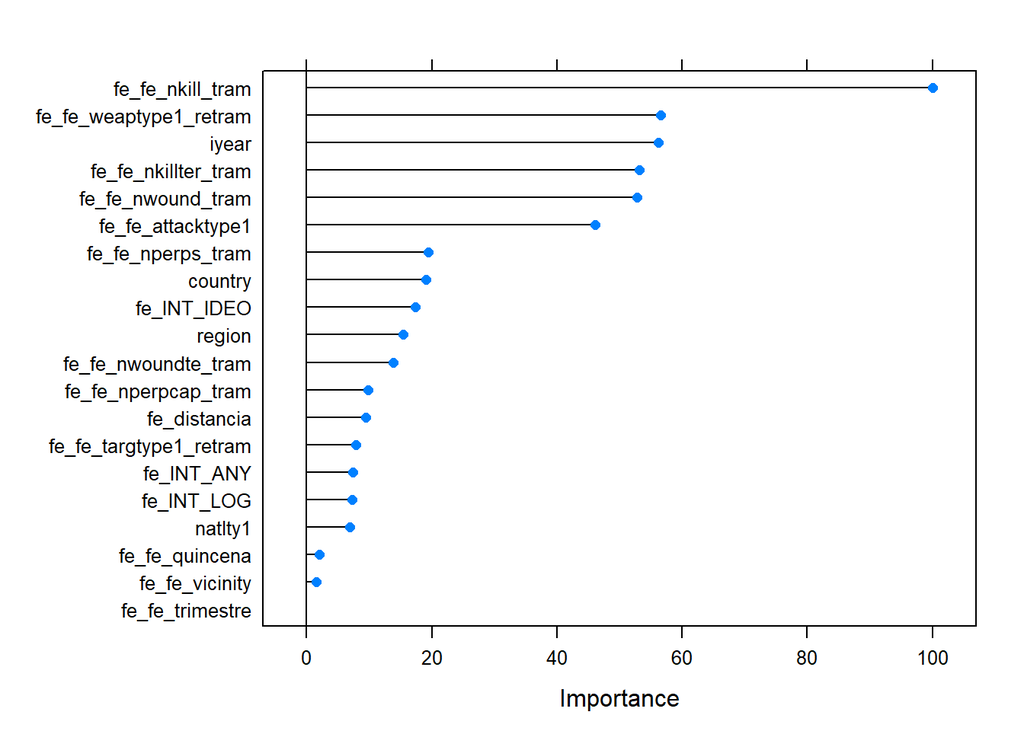

```r
#Gráfico de las variables más importantes para el modelo
plot(varImp(modelo2_glm_es2))
```

Con la base de datos, en el que algunas de las variables numéricas han sido tramificadas, el ranking de la **importancia** de las **variables** en el modelo **ha cambiado**.

**‘Nkill’** **sigue** siendo la variable **más importante**, con diferencia, seguida de **‘iyear’**, **‘nkillter’**, **‘nwound’**, **‘weaptype’** y **‘attacktype1’**.

## 4.2 Algoritmo ‘LDA’

A continuación, voy a utilizar el algoritmo linear Discriminat Analysis. Es un **método de clasificación supervisado** de variables cualitativas en el que dos o más grupos son conocidos a priori y nuevas observaciones se clasifican en uno de ellos en función de sus características. Es una **alternativa** al **algoritmo de regresión logística** cuando **existen múltiples clases** en la variable objetivo.

- **Ventajas**:
  - **Si** las **clases** están **bien separadas**, los **parámetros estimados** **en** el modelo de **regresión logística** son **inestables**. En el método de **LDA** **no sufre este problema**.
  - **Si** el número de **observaciones** es **bajo** **y** la **distribución** de los **predictores** es **aproximadamente normal** en cada una de las clases, **LDA es más estable** que la regresión logística.
  - Da **estimaciones** de qué **variables** son **importantes** en la clasificación.
- **Incovenientes**:
  - Cada **predictor** debe seguir una **distribución normal** en cada una de sus clases. **Cuando** la condición de normalidad **no se cumple**, el LDA **pierde precisión**.
  - Al igual que en el ‘GLM’, debemos **escalar** los **datos**.

### 4.2.1 Algoritmo ‘LDA’ para el escenario 1.

```r
#Creo la función de control con validación cruzada y así evitar el Overfiting
control <- trainControl(
  method = 'cv',
  number = 5

)
set.seed(7)
modelo3_LDA_es1 <- train(
  varObj ~ .,
  data = train_es1,
  method = 'lda',
  metric = 'Accuracy',
  trControl = control,
  preProc = c('center', 'scale') #Escalamos los datos
)
```

- **Resultados del modelo.**

```r
#Imprimimos las métricas del modelo en Train
print(modelo3_LDA_es1)
```

```
## Linear Discriminant Analysis
##
## 153172 samples
##     20 predictor
##      2 classes: 'No', 'Yes'
##
## Pre-processing: centered (20), scaled (20)
## Resampling: Cross-Validated (5 fold)
## Summary of sample sizes: 122538, 122537, 122538, 122538, 122537
## Resampling results:
##
##   Accuracy  Kappa
##   0.886696  -6.94565e-05
```

Con el data train obtenemos Accuracy del 88%

- **Evaluación del modelo**

Evaluamos el modelo teniendo en cuenta los datos de test.

```r
library(MLmetrics)

prediciones_modelo3_LDA_es1 <- predict(modelo3_LDA_es1, newdata = test_es1)
confusionMatrix(test_es1$varObj, prediciones_modelo3_LDA_es1, positive = "Yes")
```

```
## Confusion Matrix and Statistics
##
##           Reference
## Prediction    No   Yes
##        No      0  4333
##        Yes     5 33954
##
##                Accuracy : 0.8867
##                  95% CI : (0.8835, 0.8899)
##     No Information Rate : 0.9999
##     P-Value [Acc > NIR] : 1
##
##                   Kappa : -3e-04
##
##  Mcnemar's Test P-Value : <2e-16
##
##             Sensitivity : 0.8868
##             Specificity : 0.0000
##          Pos Pred Value : 0.9999
##          Neg Pred Value : 0.0000
##              Prevalence : 0.9999
##          Detection Rate : 0.8867
##    Detection Prevalence : 0.8868
##       Balanced Accuracy : 0.4434
##
##        'Positive' Class : Yes
##
```

```r
#Recall(y_true = test_es1$varObj, y_pred = prediciones_modelo3_LDA, positive = "Yes")
```

Vemos como en test, tenemos un Accuracy del 88.68%, igual que el alcanzado en test, por lo que, **no** tenemos **overfitting**.

Si observamos la matriz de confusión, podemos ver que de los 5 atentados que en realidad no son exitosos, el modelo no ha sido capaz de reconocer a ninguno, de 38287 que son en realidad atentados exitosos, el modelo reconoce a 33954 (hay 4333 falsos negativos).

Es decir, tenemos una **capacidad de reconocer** los **atentados exitosos** del **88.68%** (Recall-‘Yes’: Sensibildad) y una capacidad de clasificar lo atentados **no exitosos** del **0%!!** (Recall - ’No: Especifidad). Este modelo no serviría ya que no ha sido capaz de reconocer ningún caso no exitoso.

Esto se ve reflejado en la **capacidad media** de reconocer los casos correctamente , **tanto exitosos** como **no exitosos**, es del **44%** (Balanced Accuracy: Media de los ‘Recall’ en las dos clases), porcentaje más bajo que el obtenido hasta entonces.

En cuanto a la **‘Precisión’** del modelo, es decir, cuanto de confiable es el modelo en clasificar correctamente, tenemos que en los **casos exitosos**, el modelo tiene una precisión muy alta, **99.99%**. **Y** el nivel de precisión en los casos **no exitosos**, es del **0%**.

Este **modelo no es bueno**, ya que **no nos clasifica ningún caso no exitoso**. Esto es lógico ya que muchas de las distribuciones de las variables predictoras no se asemejan a una Normal.

- **Importancia de cada variable.**

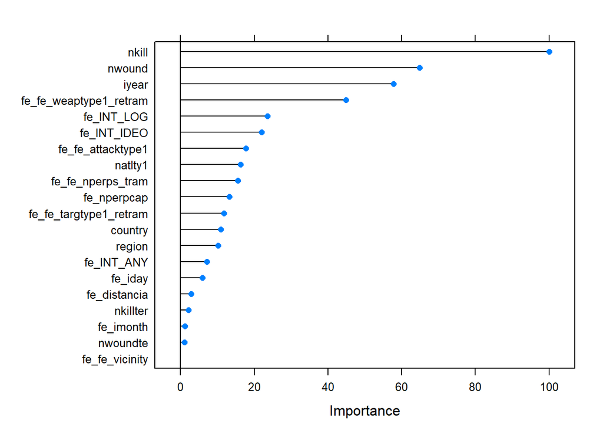

```r
#Gráfico de las variables más influyentes en el modelo
plot(varImp(modelo3_LDA_es1))
```

Las tres **variables más importantes** para este modelo son **‘nkill’**, **‘iyear’** y **‘nwound’**.

### 4.2.2 Algoritmo ‘LDA’ para el escenario 2.

Probamos el algoritmo LDA con el conjunto de datos dónde hay **variables recategorizadas**.

```r
#Creo la función de control con validación cruzada y así evitar el Overfiting
control <- trainControl(
  method = 'cv',
  number = 5

)
set.seed(7)
modelo4_LDA_es2 <- train(
  varObj ~ .,
  data = train_es2,
  method = 'lda',
  metric = 'Accuracy',
  trControl = control,
  preProc = c('center', 'scale') #Escalamos los datos
)
```

- **Resultados del modelo.**

```r
#Imprimimos las métricas del modelo en Train
print(modelo4_LDA_es2)
```

```
## Linear Discriminant Analysis
##
## 153172 samples
##     20 predictor
##      2 classes: 'No', 'Yes'
##
## Pre-processing: centered (20), scaled (20)
## Resampling: Cross-Validated (5 fold)
## Summary of sample sizes: 122538, 122537, 122538, 122538, 122537
## Resampling results:
##
##   Accuracy   Kappa
##   0.8888504  0.04631501
```

Con el data train obtenemos un accuracy del 88.88%

- **Evaluación del modelo**

Evaluamos el modelo teniendo en cuenta los datos de test.

```r
library(MLmetrics)

prediciones_modelo4_LDA_es2 <- predict(modelo4_LDA_es2, newdata = test_es2)
confusionMatrix(test_es2$varObj, prediciones_modelo4_LDA_es2, positive = "Yes")
```

```
## Confusion Matrix and Statistics
##
##           Reference
## Prediction    No   Yes
##        No    122  4211
##        Yes    53 33906
##
##                Accuracy : 0.8886
##                  95% CI : (0.8855, 0.8918)
##     No Information Rate : 0.9954
##     P-Value [Acc > NIR] : 1
##
##                   Kappa : 0.0457
##
##  Mcnemar's Test P-Value : <2e-16
##
##             Sensitivity : 0.88952
##             Specificity : 0.69714
##          Pos Pred Value : 0.99844
##          Neg Pred Value : 0.02816
##              Prevalence : 0.99543
##          Detection Rate : 0.88546
##    Detection Prevalence : 0.88684
##       Balanced Accuracy : 0.79333
##
##        'Positive' Class : Yes
##
```

Vemos como en test, tenemos un Accuracy del 88.8%, igual que el alcanzado en test, por que, **no** tenemos **overfitting**.

Si observamos la matriz de confusión, podemos ver que de los 175 atentados que en realidad no son exitosos, el modelo ha sido capaz de reconocer a 122 (hay 53 falsos positivos), de 38117 que son en realidad atentados exitosos, el modelo reconoce a 33906 (hay 4211 falsos negativos).

Es decir, tenemos una **capacidad de reconocer** los **atentados exitosos** del **88.95%** (Recall-‘Yes’: Sensibildad) y una capacidad de clasificar lo atentados **no exitosos** del **69.71%** (Recall - ’No: Especifidad). Con los **datos** del **escenario 2**, hemos conseguido **subir** la **capacidad** de **clasificar** los **atentados no exitosos**.

Esto se ve reflejado en la **capacidad media** de reconocer los casos correctamente , **tanto exitosos** como **no exitosos**, es del **79.33%** (Balanced Accuracy: Media de los ‘Recall’ en las dos clases), porcentaje más alto que el obtenido hasta entonces.

En cuanto a la **‘Precisión’** del modelo, es decir, cuanto de confiable es el modelo en clasificar correctamente, tenemos que en los **casos exitosos**, el modelo tiene una precisión muy alta, **99.84%**. **Y** el nivel de precisión en los casos **no exitosos**, es del **2%**.

Este **modelo**, ha **mejorado** en la **capacidad de reconocer** los **casos no exitosos**, **pero** la **precisión** en estos casos, es **muy baja** (2%). Son datos muy parecidos a los obtenidos por el segundo modelo del glm.

- **Importancia de cada variable.**

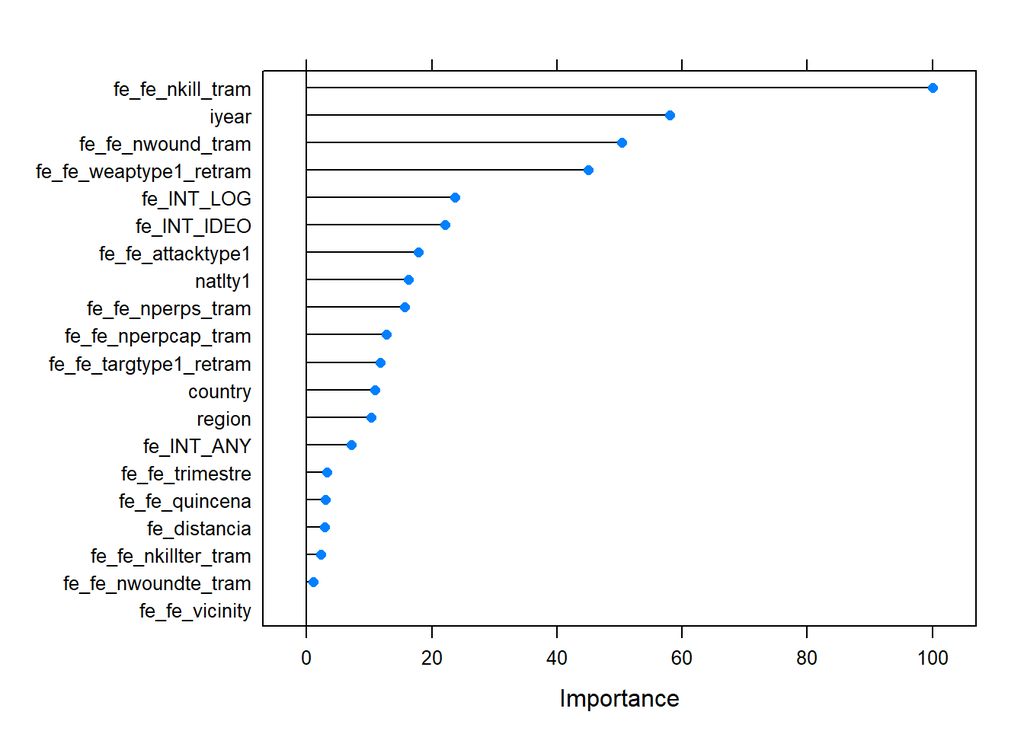

```r
#Gráfico de las variables más influyentes en el modelo
plot(varImp(modelo4_LDA_es2))
```

Las tres **variables más importantes** para este modelo son **‘nkill’**, **iyear’** y **‘nwound’**.

## 4.3 Algoritmo ‘Ranger’

A continuación, voy a utilizar el **método ‘Ranger’** basado en **Random Forest**.

Este tipo de algoritmos, es una **combinación** de **árboles de precisión**, tal que, cada árbol depende de los valores de un vector aleatorio probado independientemente y con la misma distribución para cada uno de estos.

- **Ventajas**:
  - Es un algoritmo que **funciona muy bien** en problemas de **clasificación**.
  - Es **independiente** de las **transformaciones** sobre las **variables**.
  - **No** es **necesario estandarizar** los datos.
  - **Captura** muy bien las **interacciones** entre las variables.
  - **Eficiente** en **bases** de **datos grandes**.
  - **Robusto** ante **outliers**.
  - Da **estimaciones** de qué **variables** son **importantes** en la clasificación.
- **Incovenientes**:
  - **Tendencia** a **sobre-ajustar**, sobre todo si no se regularizan. A veces , es **mejor** quedarnos con **menos parámetros**, para no provocar que exista overfiting.
  - La **clasificación** es **difícil** de **interpretar**.

### 4.3.1 Algoritmo ‘Ranger’ para el escenario 1.

```r
#Introduzco cv para evitar overfitting
train.control <- trainControl(method = "repeatedcv", number = 5,
                              repeats = 5,
                              returnResamp = "final", verboseIter = TRUE,                                        savePredictions = TRUE,
                              allowParallel = TRUE)

#Fijo la semilla
set.seed(7)

#En principio incluyo los mismos hiperparámetros anteriores (son los que vienen por defecto en 'ranger')
hyperparameters <- expand.grid(mtry = 0,
                               min.node.size = 0,
                               splitrule = "gini")

#Construyo el modelo a entrenar
modelo5_ranger_es1  <- train(x = train_es1[,c(1:20)],
                             y= train_es1$varObj,
                             method = "ranger",
                             tuneGrid = hyperparameters,
                             metric = 'Accuracy',
                             importance= 'impurity', #Para poder ver qué variable                                discrimina mejor
                             trControl = train.control,
                             num.trees = 5, #Número de árboles
                             verbose = TRUE,
                             classification = TRUE,
                             alpha = 1, #Modelo Lasso
                             regularization.usedepth = TRUE)
```

- **Resultados del modelo.**

```r
#Imprimimos las métricas del modelo en Train
print(modelo5_ranger_es1)
```

```
## Random Forest
##
## 153172 samples
##     20 predictor
##      2 classes: 'No', 'Yes'
##
## No pre-processing
## Resampling: Cross-Validated (5 fold, repeated 5 times)
## Summary of sample sizes: 122538, 122537, 122538, 122538, 122537, 122538, ...
## Resampling results:
##
##   Accuracy   Kappa
##   0.9213133  0.5505319
##
## Tuning parameter 'mtry' was held constant at a value of 0
## Tuning
##  parameter 'splitrule' was held constant at a value of gini
## Tuning
##  parameter 'min.node.size' was held constant at a value of 0
```

El ajuste del modelo en train es del 92.13%

- **Evaluación del modelo**

Evaluamos el modelo teniendo en cuenta los datos de test.

```r
#Matriz de confusión y metricas del modelo en test
prediciones_modelo5_ranger_es1 <- predict(modelo5_ranger_es1, test_es1)
confusionMatrix(prediciones_modelo5_ranger_es1, test_es1$varObj,positive = "Yes" )
```

```
## Confusion Matrix and Statistics
##
##           Reference
## Prediction    No   Yes
##        No   2209   846
##        Yes  2124 33113
##
##                Accuracy : 0.9224
##                  95% CI : (0.9197, 0.9251)
##     No Information Rate : 0.8868
##     P-Value [Acc > NIR] : < 2.2e-16
##
##                   Kappa : 0.5565
##
##  Mcnemar's Test P-Value : < 2.2e-16
##
##             Sensitivity : 0.9751
##             Specificity : 0.5098
##          Pos Pred Value : 0.9397
##          Neg Pred Value : 0.7231
##              Prevalence : 0.8868
##          Detection Rate : 0.8647
##    Detection Prevalence : 0.9202
##       Balanced Accuracy : 0.7424
##
##        'Positive' Class : Yes
##
```

Vemos como en test, tenemos un Accuracy del 92.24%, mismo nivel que el alcanzado en test, por lo que, **no** tenemos **overfitting**.

Si observamos la matriz de confusión, podemos ver que de los 4333 atentados que en realidad no son exitosos, el modelo ha sido capaz de reconocer a 2209 (hay 2124 falsos positivos), de 33959 que son en realidad atentados exitosos, el modelo reconoce a 33113 (hay 846 falsos negativos).

Es decir, tenemos una **capacidad de reconocer** los **atentados exitosos** del **97.51%** (Recall-‘Yes’: Sensibildad) y una capacidad de clasificar lo atentados **no exitosos** del **50.98%** (Recall - ’No: Especifidad). Un porcentaje todavía bajo.

Esto se ve reflejado en la **capacidad media** de reconocer los casos correctamente , **tanto exitosos** como **no exitosos**, es del **74.24%** (Balanced Accuracy: Media de los ‘Recall’ en las dos clases).

En cuanto a la **‘Precisión’** del modelo, es decir, cuanto de confiable es el modelo en clasificar correctamente, tenemos que en los **casos exitosos**, el modelo tiene una precisión muy alta, **93.97%**. **Y** el nivel de precisión en los casos **no exitosos**, es del **72.31%**. Hemos conseguido **subir** la **fiabilidad** del modelo en **clasificar** los **atentados no exitosos**.

Este **modelo**, ha **mejorado tanto** la **precisión** de reconocer** los **casos no exitosos**, aunque la capacidad todavía es muy baja (51%).

Podemos observar que las **métricas** en los casos positivos, son bastantes **altas**, por lo que, habrá que tener especial cuidado de **no** llegar a **ocasionar overfitting**, para evitarlo **controlaré** el **ajuste** de los **hiperparámetros** (‘mtry’, ‘max_depth’ y ‘min.node.size’)

- **Importancia de cada variable.**

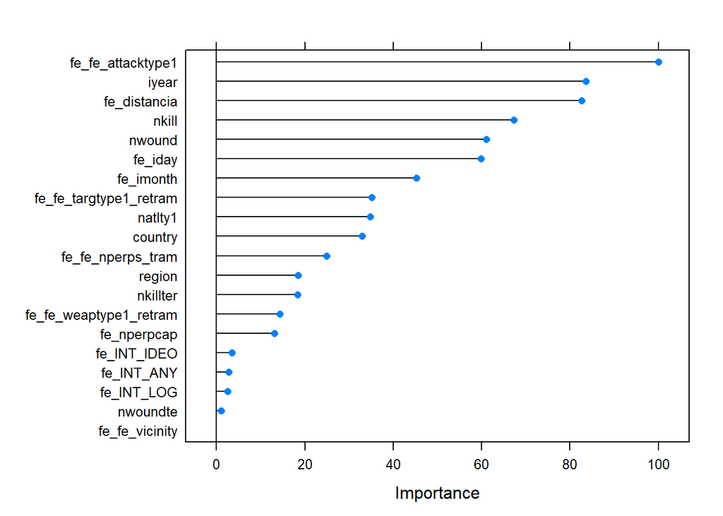

```r
#Gráfico de las variables más influyentes
plot(varImp(modelo5_ranger_es1))
```

Las **tres** variables **más importantes**, con diferencia, para este modelo son: **‘attacktype1’**, **‘distancia’** y **‘iyear’**, seguidas a un nivel menor, pero todavia por encima del 50%, **‘nwound’**, **‘nkill’** e **‘iday’**.

### 4.3.2 Algoritmo ‘Ranger’ para el escenario 2.

Ahora utilizaré el **mismo algoritmo** pero con los **datos** del **escenario 2**, dónde aparecen algunas de las variables numéricas recategorizadas.

```r
#Introduzco cv para evitar overfitting
train.control <- trainControl(method = "repeatedcv", number = 5,
                              repeats = 5,
                              returnResamp = "final", verboseIter = TRUE,                                        savePredictions = TRUE,
                              allowParallel = TRUE)

#Fijo la semilla
set.seed(7)

#En principio incluyo los mismos hiperparámetros anteriores (son los que vienen por defecto en 'ranger')
hyperparameters <- expand.grid(mtry = 0,
                               min.node.size = 0,
                               splitrule = "gini")

#Construyo el modelo a entrenar
modelo6_ranger_es2  <- train(x = train_es2[,c(1:20)],
                             y= train_es2$varObj,
                             method = "ranger",
                             tuneGrid = hyperparameters,
                             metric = 'Accuracy',
                             importance= 'impurity', #Para poder ver qué variable                                discrimina mejor
                             trControl = train.control,
                             num.trees = 5, #Número de árboles
                             verbose = TRUE,
                             classification = TRUE,
                             alpha = 1, #Modelo Lasso
                             regularization.usedepth = TRUE)
```

- **Resultados del modelo.**

```r
#Imprimimos las métricas del modelo en Train
print(modelo6_ranger_es2)
```

```
## Random Forest
##
## 153172 samples
##     20 predictor
##      2 classes: 'No', 'Yes'
##
## No pre-processing
## Resampling: Cross-Validated (5 fold, repeated 5 times)
## Summary of sample sizes: 122538, 122537, 122538, 122538, 122537, 122538, ...
## Resampling results:
##
##   Accuracy   Kappa
##   0.9217742  0.5535277
##
## Tuning parameter 'mtry' was held constant at a value of 0
## Tuning
##  parameter 'splitrule' was held constant at a value of gini
## Tuning
##  parameter 'min.node.size' was held constant at a value of 0
```

Con el data train obtenemos un accuracy del 92.17%

- **Evaluación del modelo**

Evaluamos el modelo teniendo en cuenta los datos de test.

```r
#Matriz de confusión y metricas del modelo en test
prediciones_modelo6_ranger_es2 <- predict(modelo6_ranger_es2, test_es2)
confusionMatrix(prediciones_modelo6_ranger_es2, test_es2$varObj,positive = "Yes" )
```

```
## Confusion Matrix and Statistics
##
##           Reference
## Prediction    No   Yes
##        No   2209   881
##        Yes  2124 33078
##
##                Accuracy : 0.9215
##                  95% CI : (0.9188, 0.9242)
##     No Information Rate : 0.8868
##     P-Value [Acc > NIR] : < 2.2e-16
##
##                   Kappa : 0.5531
##
##  Mcnemar's Test P-Value : < 2.2e-16
##
##             Sensitivity : 0.9741
##             Specificity : 0.5098
##          Pos Pred Value : 0.9397
##          Neg Pred Value : 0.7149
##              Prevalence : 0.8868
##          Detection Rate : 0.8638
##    Detection Prevalence : 0.9193
##       Balanced Accuracy : 0.7419
##
##        'Positive' Class : Yes
##
```

Vemos como en test, tenemos un Accuracy del 92.15%, mismo nivel que el alcanzado en test, por lo que, **no** tenemos **overfitting**.

Si observamos la matriz de confusión, podemos ver que de los 4333 atentados que en realidad no son exitosos, el modelo ha sido capaz de reconocer a 2209 (hay 2124 falsos positivos), de 33959 que son en realidad atentados exitosos, el modelo reconoce a 33078 (hay 881 falsos negativos).

Es decir, tenemos una **capacidad de reconocer** los **atentados exitosos** del **97.41%** (Recall-‘Yes’: Sensibildad) y una capacidad de clasificar lo atentados **no exitosos** del **50.98%** (Recall - ’No: Especifidad). Un porcentaje todavía bajo.

Esto se ve reflejado en la **capacidad media** de reconocer los casos correctamente , **tanto exitosos** como **no exitosos**, es del **74.19%** (Balanced Accuracy: Media de los ‘Recall’ en las dos clases), porcentaje muy parecido alcanzado con el modelo ranger y con los datos del escenario 1.

En cuanto a la **‘Precisión’** del modelo, es decir, cuanto de confiable es el modelo en clasificar correctamente, tenemos que en los **casos exitosos**, el modelo tiene una precisión muy alta, **93.97%**. **Y** el nivel de precisión en los casos **no exitosos**, es del **71.49%**. Mantenemos, la **fiabilidad** del modelo en **clasificar** los **atentados no exitosos**, respecto al modelo anterior con el escenario 1.

Con los datos del escenario 2, no hemos conseguido mejorar el nivel de predicción, respecto a los modelos anteriores.

- **Importancia de cada variable.**

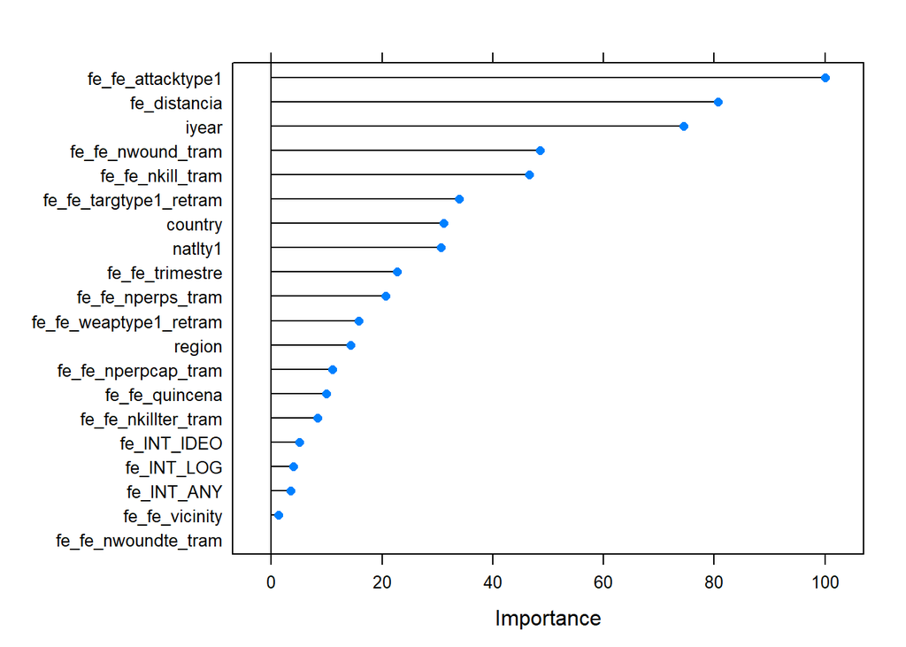

```r
#Gráfico de las variables más influyentes
plot(varImp(modelo6_ranger_es2))
```

### 4.3.3 Algoritmo ‘Ranger’ con grid-search para el escenario 1.

Aplico un grid-search en ciertos parámetros del algoritmo Ranger.

```r
#Introduzco cv para evitar overfitting
train.control <- trainControl(method = "repeatedcv", number = 5,
                              repeats = 5,
                              returnResamp = "final", verboseIter = TRUE,                                        savePredictions = TRUE,
                              allowParallel = TRUE)

#En principio incluyo los mismos hiperparámetros anteriores (son los que vienen por defecto en 'ranger')
hyperparameters <- expand.grid(mtry = c(5, 6, 7),
                               min.node.size = c(1, 3, 5),
                               splitrule = "gini")
#Fijo la semilla
set.seed(7)

#Construyo el modelo a entrenar
modelo7_ranger_grid_es1  <- train(x = train_es1[,c(1:20)],
                             y= train_es1$varObj,
                             method = "ranger",
                             tuneGrid = hyperparameters,
                             metric = 'Accuracy',
                             importance= 'impurity', #Para poder ver qué variable                                discrimina mejor
                             trControl = train.control,
                             alpha = 1,
                             max.depth = 5,
                             num.trees = 100, #Número de árboles
                             verbose = TRUE,
                             classification = TRUE,
                             regularization.usedepth = TRUE)
```

```r
# assess top 10 models
print(modelo7_ranger_grid_es1)
```

```
## Random Forest
##
## 153172 samples
##     20 predictor
##      2 classes: 'No', 'Yes'
##
## No pre-processing
## Resampling: Cross-Validated (5 fold, repeated 5 times)
## Summary of sample sizes: 122538, 122537, 122538, 122538, 122537, 122538, ...
## Resampling results across tuning parameters:
##
##   mtry  min.node.size  Accuracy   Kappa
##   5     1              0.8868579  0.0005925554
##   5     3              0.8868827  0.0009956793
##   5     5              0.8868553  0.0005513321
##   6     1              0.8875591  0.0116771871
##   6     3              0.8875016  0.0107129114
##   6     5              0.8877719  0.0152063711
##   7     1              0.8886598  0.0293277886
##   7     3              0.8887969  0.0315504313
##   7     5              0.8885606  0.0277217059
##
## Tuning parameter 'splitrule' was held constant at a value of gini
## Accuracy was used to select the optimal model using the largest value.
## The final values used for the model were mtry = 7, splitrule = gini
##  and min.node.size = 3.
```

Vemos que los parámetros más óptimos para este modelo son mtry = 7 y min.node.size = 3

Por lo que, introduciré estos parámetros de nuevo en el Algoritmo.

```r
#Fijo la semilla
set.seed(7)

#Construyo el modelo a entrenar
modelo7_ranger_grid_es1 <- ranger(
  varObj ~ .,
  data = train_es1,
  num.trees = 100,
  max.depth = 5,
  mtry = 7,
  alpha = 1, #Modelo Lasso
  importance = 'impurity',
  write.forest = TRUE,
  min.node.size = 3,
  splitrule = 'gini',
  verbose = TRUE,
  classification = TRUE,
  regularization.usedepth = TRUE
)
```

- **Resultados del modelo.**

```r
#Imprimimos las métricas del modelo en Train
print(modelo7_ranger_grid_es1)
```

```
## Ranger result
##
## Call:
##  ranger(varObj ~ ., data = train_es1, num.trees = 100, max.depth = 5,      mtry = 7, alpha = 1, importance = "impurity", write.forest = TRUE,      min.node.size = 3, splitrule = "gini", verbose = TRUE, classification = TRUE,      regularization.usedepth = TRUE)
##
## Type:                             Classification
## Number of trees:                  100
## Sample size:                      153172
## Number of independent variables:  20
## Mtry:                             7
## Target node size:                 3
## Variable importance mode:         impurity
## Splitrule:                        gini
## OOB prediction error:             11.03 %
```

Con este modelo obtengo una capacidad predictiva, con los datos de train, del 88.97%

- **Evaluación del modelo**

Evaluamos el modelo teniendo en cuenta los datos de test.

```r
#Matriz de confusión y metricas del modelo en test
prediciones_modelo7_ranger_grid_es1 <- predict(modelo7_ranger_grid_es1, test_es1)
confusionMatrix(prediciones_modelo7_ranger_grid_es1$predictions, test_es1$varObj,positive = "Yes" )
```

```
## Confusion Matrix and Statistics
##
##           Reference
## Prediction    No   Yes
##        No     79     6
##        Yes  4254 33953
##
##                Accuracy : 0.8887
##                  95% CI : (0.8856, 0.8919)
##     No Information Rate : 0.8868
##     P-Value [Acc > NIR] : 0.1209
##
##                   Kappa : 0.0315
##
##  Mcnemar's Test P-Value : <2e-16
##
##             Sensitivity : 0.99982
##             Specificity : 0.01823
##          Pos Pred Value : 0.88866
##          Neg Pred Value : 0.92941
##              Prevalence : 0.88684
##          Detection Rate : 0.88669
##    Detection Prevalence : 0.99778
##       Balanced Accuracy : 0.50903
##
##        'Positive' Class : Yes
##
```

En test, tenemos un Accuracy del 88.86%, mismo nivel que el alcanzado en test, por lo que, **no** tenemos **overfitting**.

Si observamos la matriz de confusión, podemos ver que de los 4333 atentados que en realidad no son exitosos, el modelo ha sido capaz de reconocer a 79 (hay 4254 falsos positivos), de 33959 que son en realidad atentados exitosos, el modelo reconoce a 33953 (hay 6 falsos negativos).

Es decir, tenemos una **capacidad de reconocer** los **atentados exitosos** del **99.98%** (Recall-‘Yes’: Sensibildad) y una capacidad de clasificar lo atentados **no exitosos** del **1%!!** (Recall - ’No: Especifidad). Un porcentaje **demasiado bajo**.

Esto se ve reflejado en la **capacidad media** de reconocer los casos correctamente , **tanto exitosos** como **no exitosos**, es del **50%** (Balanced Accuracy: Media de los ‘Recall’ en las dos clases), es decir, clasifica muy bien los atentados exitosos y nada los no exitosos.

En cuanto a la **‘Precisión’** del modelo, es decir, cuanto de confiable es el modelo en clasificar correctamente, tenemos que en los **casos exitosos**, el modelo tiene una precisión del **88.86%**. **Y** el nivel de precisión en los casos **no exitosos**, es del **92%**. Pero no debemos tenerlo en cuenta, ya que sólo ha sido capaz de clasificar el 1% de los no exitosos.

Este **modelo sólo clasifica bien** los atentados exitosos, y no es capaz de clasificar los atentados no exitosos.

- **Importancia de cada variable.**

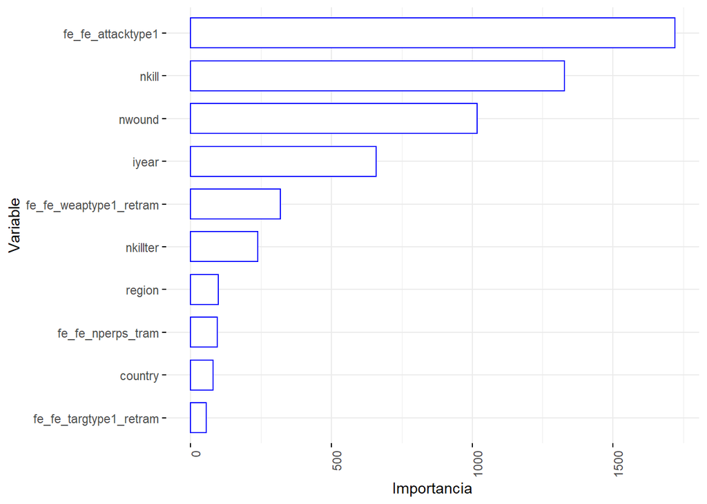

```r
#Variables más importantes del modelo
library(ggpubr)
vars_imp <- modelo7_ranger_grid_es1$variable.importance
vars_imp <- as.data.frame(vars_imp)
vars_imp$myvar <- row.names(vars_imp)
vars_imp <- as.data.table(vars_imp)
setorder(vars_imp,-vars_imp)
ggbarplot(vars_imp[1:10],
          x = 'myvar',
          y = 'vars_imp',
          color = 'blue',
          palette = 'jco',
          sort.val = 'asc',
          sort.by.groups = FALSE,
          x.text.angle = 90,
          ylab = 'Importancia',
          xlab = 'Variable',
          rotate = TRUE,
          ggtheme = theme_minimal()
)
```

Las variables más influyentes del modelo son: **‘attacktype1’**, **‘nkill’** y **‘nwound’**.

### 4.3.4 Algoritmo ‘Ranger’ con grid-search para el escenario 2.

A continuación,voy a utilizar el mismo algoritmo anterior, con grid research y para el conjunto de datos del escenario 2.

```r
#Introduzco cv para evitar overfitting
train.control <- trainControl(method = "repeatedcv", number = 5,
                              repeats = 5,
                              returnResamp = "final", verboseIter = TRUE,                                        savePredictions = TRUE,
                              allowParallel = TRUE)

#En principio incluyo los mismos hiperparámetros anteriores (son los que vienen por defecto en 'ranger')
hyperparameters <- expand.grid(mtry = c(5, 6, 7),
                               min.node.size = c(1, 3, 5),
                               splitrule = "gini")
#Fijo la semilla
set.seed(7)
#Construyo el modelo a entrenar
modelo8_ranger_grid_es2  <- train(x = train_es2[,c(1:20)],
                             y= train_es2$varObj,
                             method = "ranger",
                             tuneGrid = hyperparameters,
                             metric = 'Accuracy',
                             importance= 'impurity', #Para poder ver qué variable                                discrimina mejor
                             trControl = train.control,
                             alpha = 1,
                             max.depth = 5,
                             num.trees = 100, #Número de árboles
                             verbose = TRUE,
                             classification = TRUE,
                             regularization.usedepth = TRUE)
```

```r
# assess top 10 models
print(modelo8_ranger_grid_es2)
```

```
## Random Forest
##
## 153172 samples
##     20 predictor
##      2 classes: 'No', 'Yes'
##
## No pre-processing
## Resampling: Cross-Validated (5 fold, repeated 5 times)
## Summary of sample sizes: 122538, 122537, 122538, 122538, 122537, 122538, ...
## Resampling results across tuning parameters:
##
##   mtry  min.node.size  Accuracy   Kappa
##   5     1              0.8870263  0.003242811
##   5     3              0.8872562  0.006963519
##   5     5              0.8871634  0.005574757
##   6     1              0.8895229  0.043227037
##   6     3              0.8891965  0.037948639
##   6     5              0.8891743  0.037462901
##   7     1              0.8937208  0.107678672
##   7     3              0.8940315  0.112642521
##   7     5              0.8943005  0.116818340
##
## Tuning parameter 'splitrule' was held constant at a value of gini
## Accuracy was used to select the optimal model using the largest value.
## The final values used for the model were mtry = 7, splitrule = gini
##  and min.node.size = 5.
```

Vemos que los parámetros más óptimos para este modelo son mtry = 7 y min.node.size = 5

Por lo que, introduciré estos parámetros de nuevo en el Algoritmo.

```r
#Fijo la semilla
set.seed(7)

#Construyo el modelo a entrenar
modelo8_ranger_grid_es2 <- ranger(
  varObj ~ .,
  data = train_es2,
  num.trees = 100,
  max.depth = 5,
  mtry = 7,
  alpha = 1, #Modelo Lasso
  importance = 'impurity',
  write.forest = TRUE,
  min.node.size = 5,
  splitrule = 'gini',
  verbose = TRUE,
  classification = TRUE,
  regularization.usedepth = TRUE
)
```

- **Resultados del modelo.**

```r
#Imprimimos las métricas del modelo en Train
print(modelo8_ranger_grid_es2)
```

```
## Ranger result
##
## Call:
##  ranger(varObj ~ ., data = train_es2, num.trees = 100, max.depth = 5,      mtry = 7, alpha = 1, importance = "impurity", write.forest = TRUE,      min.node.size = 5, splitrule = "gini", verbose = TRUE, classification = TRUE,      regularization.usedepth = TRUE)
##
## Type:                             Classification
## Number of trees:                  100
## Sample size:                      153172
## Number of independent variables:  20
## Mtry:                             7
## Target node size:                 5
## Variable importance mode:         impurity
## Splitrule:                        gini
## OOB prediction error:             10.49 %
```

Con este modelo obtengo una capacidad predictiva, con los datos de train, del 89.51%

- **Evaluación del modelo**

Evaluamos el modelo teniendo en cuenta los datos de test.

```r
#Matriz de confusión y metricas del modelo en test
prediciones_modelo8_ranger_grid_es2 <- predict(modelo8_ranger_grid_es2, test_es2)
confusionMatrix(prediciones_modelo8_ranger_grid_es2$predictions, test_es2$varObj,positive = "Yes" )
```

```
## Confusion Matrix and Statistics
##
##           Reference
## Prediction    No   Yes
##        No    319    36
##        Yes  4014 33923
##
##                Accuracy : 0.8942
##                  95% CI : (0.8911, 0.8973)
##     No Information Rate : 0.8868
##     P-Value [Acc > NIR] : 2.117e-06
##
##                   Kappa : 0.121
##
##  Mcnemar's Test P-Value : < 2.2e-16
##
##             Sensitivity : 0.99894
##             Specificity : 0.07362
##          Pos Pred Value : 0.89419
##          Neg Pred Value : 0.89859
##              Prevalence : 0.88684
##          Detection Rate : 0.88590
##    Detection Prevalence : 0.99073
##       Balanced Accuracy : 0.53628
##
##        'Positive' Class : Yes
##
```

En test, tenemos un Accuracy del 89.4%, mismo nivel que el alcanzado en test, por lo que, **no** tenemos **overfitting**.

Si observamos la matriz de confusión, podemos ver que de los 4333 atentados que en realidad no son exitosos, el modelo ha sido capaz de reconocer a 319 (hay 4014 falsos positivos), de 33959 que son en realidad atentados exitosos, el modelo reconoce a 33923 (hay 36 falsos negativos).

Es decir, tenemos una **capacidad de reconocer** los **atentados exitosos** del **99.89%** (Recall-‘Yes’: Sensibildad) y una capacidad de clasificar lo atentados **no exitosos** del **7%!!** (Recall - ’No: Especifidad). Un porcentaje **demasiado bajo**, aunque con estos datos (escenario 2), hemos mejorado muy poco respecto al modelo anterior.

Esto se ve reflejado en la **capacidad media** de reconocer los casos correctamente , **tanto exitosos** como **no exitosos**, es del **53%** (Balanced Accuracy: Media de los ‘Recall’ en las dos clases).

En cuanto a la **‘Precisión’** del modelo, es decir, cuanto de confiable es el modelo en clasificar correctamente, tenemos que en los **casos exitosos**, el modelo tiene una precisión del **89.41%**. **Y** el nivel de precisión en los casos **no exitosos**, es del **89.85%**. Pero no debemos tenerlo en cuenta, ya que sólo ha sido capaz de clasificar el 7% de los no exitosos.

Este **modelo sólo clasifica bien** los atentados exitosos, y no es capaz de clasificar los atentados no exitosos.

- **Importancia de cada variable.**

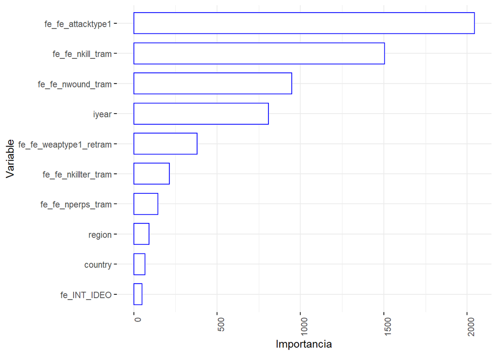

```r
#Variables más importantes del modelo
library(ggpubr)
vars_imp <- modelo8_ranger_grid_es2$variable.importance
vars_imp <- as.data.frame(vars_imp)
vars_imp$myvar <- row.names(vars_imp)
vars_imp <- as.data.table(vars_imp)
setorder(vars_imp,-vars_imp)
ggbarplot(vars_imp[1:10],
          x = 'myvar',
          y = 'vars_imp',
          color = 'blue',
          palette = 'jco',
          sort.val = 'asc',
          sort.by.groups = FALSE,
          x.text.angle = 90,
          ylab = 'Importancia',
          xlab = 'Variable',
          rotate = TRUE,
          ggtheme = theme_minimal()
)
```

Las variables más influyentes para este modelo son: **‘attacktype1’**, **‘nkill’**, **‘nwound’** e **‘iyear’**, siendo las dos primeras las más influyentes con diferencia respecto a las demás variables predictoras.

# 5 Mundo H2O.

A continuación, utilizaré diferentes algoritmos pertenecientes a la libreria H2O, con el fin de encontrar un modelo que mejore las bondades de ajuste de los modelos anteriores.

```r
#Arrancamos el entorno h2o
h2o.init(nthreads = 6, max_mem_size = '10G')
```

[output not shown]

```r
options(java.parameters = "-Xmx1024m")
```

```r
#To speedup transformations
options('h2o.use.data.table' = TRUE)
```

## 5.1 Train/Test H2O

Transformo el data.table en objeto h2o y creo los conjuntos en Train,Test, tanto para el escenario 1 como para el escenario 2.

```r
#Transformo en objeto h2o el conjunto de datos del escenario 1
datMod_es1_hex <- as.h2o(datMod_es1, destination_frame = 'datMod_es1_hex')
#Transformo en objeto h2o el conjunto de datos del escenario 2
datMod_es2_hex <- as.h2o(datMod_es2, destination_frame = 'datMod_es2_hex')
```

A continuación, realizo las particiones en h2o, para los conjuntos de datos train, validación y test, tanto para el primer escenario como para el segundo escenario.

```r
#Particiones para train/validation/test en escenario 1
splits_es1 <- h2o.splitFrame(
  data = datMod_es1_hex,
  ratios = c(0.6, 0.2),
  destination_frames = c('train_es1_hex', 'valid_es1_hex', 'test_es1_hex'),
  seed = 1234
)
train_es1_hex <- splits_es1[[1]]
valid_es1_hex <- splits_es1[[2]]
test_es1_hex <- splits_es1[[3]]
```

```r
#Particiones para train/validation/test en escenario 2
splits_es2 <- h2o.splitFrame(
  data = datMod_es2_hex,
  ratios = c(0.6, 0.2),
  destination_frames = c('train_es2_hex', 'valid_es2_hex', 'test_es2_hex'),
  seed = 1234
)
train_es2_hex <- splits_es2[[1]]
valid_es2_hex <- splits_es2[[2]]
test_es2_hex <- splits_es2[[3]]
```

Identifico tanto las variables predictoras como la variable objetivo en ambos escenarios.

```r
#Identifico variables predictoras y objetivo para el conjunto de datos del escenario 1
y_es1 <- "varObj"
x_es1 <- setdiff(names(train_es1_hex), y_es1)
#Para clasificación binaria la variable objetivo debe ser factor
train_es1_hex[ ,y_es1] <- as.factor(train_es1_hex[ ,y_es1])
```

```r
#Identifico variables predictoras y objetivo para el conjunto de datos del escenario 2
y_es2 <- "varObj"
x_es2 <- setdiff(names(train_es2_hex), y_es2)
#Para clasificación binaria la variable objetivo debe ser factor
train_es2_hex[ ,y_es2] <- as.factor(train_es2_hex[ ,y_es2])
```

## 5.2 Algoritmo Automl

Este algoritmo esta basado en el **aprendizaje automático automatizado**. Y nos servirá como **modelo base** fijándonos en sus parámetros, para poder utilizarlos en los siguientes algoritmos, con el fin de ir optimizarlos y así mejorar el nivel de predicción de los siguientes modelos.

- **Ventajas**:
  - **No** necesita una **preparación** exahustiva de las **variables**.
  - No necesita ajuste sobre los algoritmos, ya que, **proporciona** un **ajuste automático** de **parámetros** .
  - Puede servir como **referencia** para **trabajar a partir** de él mirando **sus parámetros**.
- **Incovenientes**:
  - Nos devuelve un **modelo básico** con el que **hay** que trabajar a posteriori para poder **optimizar** los resultados.
  - En **ocasiones**, el **mejor modelo** dado por este algoritmo es un **modelo ensamblado aplidado**, formado por un conjunto de algoritmos**, por lo que será una tarea** dificil** y complicada **interpretar** la **importancia** de las **variables** dentro del modelo.

```r
#Fijo la semilla
set.seed(7)
#Entreno el modelo automl para el escenario 1 con los datos de train y validación.
aml <- h2o.automl(
  x = x_es1,
  y = y_es1,
  training_frame = train_es1_hex,
  validation_frame = valid_es1_hex,
  max_models = 5, #para que ejecute como máximo 5 modelos
  balance_classes = TRUE, #las clases no están balancedadas
  stopping_metric = 'AUTO',
  stopping_rounds = 3,
  sort_metric = 'AUTO',
  nfolds = 5, #Para evitar overfitting
  verbosity = 'info',
  set.seed(7)
)
```

```r
#View the automl leaderboard
lb <- aml@leaderboard
print(lb, n=nrow(lb))
```

```
##                                              model_id       auc   logloss
## 1    StackedEnsemble_AllModels_AutoML_20210925_211013 0.9269957 0.1891679
## 2 StackedEnsemble_BestOfFamily_AutoML_20210925_211013 0.9263810 0.1896807
## 3                        GBM_3_AutoML_20210925_211013 0.9253955 0.1951681
## 4                        GBM_2_AutoML_20210925_211013 0.9247564 0.1955519
## 5                        GBM_1_AutoML_20210925_211013 0.9229168 0.1980958
## 6                        DRF_1_AutoML_20210925_211013 0.9130105 0.2392985
## 7                        GLM_1_AutoML_20210925_211013 0.7907086 0.3072279
##       aucpr mean_per_class_error      rmse        mse
## 1 0.9883155            0.2406147 0.2337752 0.05465086
## 2 0.9881646            0.2437560 0.2339268 0.05472177
## 3 0.9883320            0.2698664 0.2380736 0.05667906
## 4 0.9882330            0.2717799 0.2388582 0.05705326
## 5 0.9879391            0.2630305 0.2409586 0.05806103
## 6 0.9856171            0.2877486 0.2622692 0.06878514
## 7 0.9626312            0.4771423 0.2977655 0.08866428
##
## [7 rows x 7 columns]
```

El modelo **ganador**, es un **Modelo ‘StackedEnsemble’**, es un algoritmo que **recoje un conjunto de algoritmos apilados**, para obtener un mejor rendimiento. Éstos admiten regresión, clasificación binaria y clasificación multiclase.

- **Resultados del modelo.**

```r
#Imprimimos las métricas del modelo en Train/Validación
modelo9_automl <- aml@leader
modelo9_automl
```

```
## Model Details:
## ==============
##
## H2OBinomialModel: stackedensemble
## Model ID:  StackedEnsemble_AllModels_AutoML_20210925_211013
## Number of Base Models: 5
##
## Base Models (count by algorithm type):
##
## drf gbm glm
##   1   3   1
##
## Metalearner:
##
## Metalearner algorithm: glm
## Metalearner cross-validation fold assignment:
##   Fold assignment scheme: AUTO
##   Number of folds: 5
##   Fold column: NULL
## Metalearner hyperparameters:
##
##
## H2OBinomialMetrics: stackedensemble
## ** Reported on training data. **
##
## MSE:  0.03816773
## RMSE:  0.1953656
## LogLoss:  0.1307154
## Mean Per-Class Error:  0.1435467
## AUC:  0.9765929
## AUCPR:  0.9971546
## Gini:  0.9531858
##
## Confusion Matrix (vertical: actual; across: predicted) for F1-optimal threshold:
##          No  Yes    Error       Rate
## No      824  295 0.263628  =295/1119
## Yes     206 8573 0.023465  =206/8779
## Totals 1030 8868 0.050616  =501/9898
##
## Maximum Metrics: Maximum metrics at their respective thresholds
```

[output cut: 85 more lines]

```
## 6                   max recall  0.030230      1.000000 394
## 7              max specificity  0.999936      0.998616   0
## 8             max absolute_mcc  0.583538      0.608515 228
## 9   max min_per_class_accuracy  0.881495      0.847567 105
## 10 max mean_per_class_accuracy  0.877442      0.848513 107
## 11                     max tns  0.999936  12991.000000   0
## 12                     max fns  0.999936  96476.000000   0
## 13                     max fps  0.000786  13009.000000 399
## 14                     max tps  0.030230 101988.000000 394
## 15                     max tnr  0.999936      0.998616   0
## 16                     max fnr  0.999936      0.945954   0
## 17                     max fpr  0.000786      1.000000 399
## 18                     max tpr  0.030230      1.000000 394
##
## Gains/Lift Table: Extract with `h2o.gainsLift(<model>, <data>)` or `h2o.gainsLift(<model>, valid=<T/F>, xval=<T/F>)`
```

Podemos ver cómo el nivel de recall/Precisión (**AUCPR**) en train es del cómo en validación es bastante elevado, pero prácticamente iguales, **99.71% en train** y en **validación del 98.91**

- **Evaluación del modelo**

Evaluamos el modelo teniendo en cuenta los datos de test.

```r
h2o.performance(modelo9_automl, newdata = test_es1_hex)
```

```
## H2OBinomialMetrics: stackedensemble
##
## MSE:  0.05512548
## RMSE:  0.2347882
## LogLoss:  0.1909853
## Mean Per-Class Error:  0.2601125
## AUC:  0.9270318
## AUCPR:  0.9877228
## Gini:  0.8540636
##
## Confusion Matrix (vertical: actual; across: predicted) for F1-optimal threshold:
##          No   Yes    Error         Rate
## No     2444  1978 0.447309   =1978/4422
## Yes     776 33041 0.022947   =776/33817
## Totals 3220 35019 0.072021  =2754/38239
##
## Maximum Metrics: Maximum metrics at their respective thresholds
##                         metric threshold        value idx
## 1                       max f1  0.452940     0.960164 274
## 2                       max f2  0.238879     0.979452 336
## 3                 max f0point5  0.732535     0.956098 175
## 4                 max accuracy  0.498595     0.928110 258
## 5                max precision  0.998605     0.998574   3
## 6                   max recall  0.032908     1.000000 395
## 7              max specificity  0.999910     0.999322   0
## 8             max absolute_mcc  0.621741     0.612759 216
## 9   max min_per_class_accuracy  0.874796     0.846852 109
## 10 max mean_per_class_accuracy  0.882213     0.848383 104
## 11                     max tns  0.999910  4419.000000   0
## 12                     max fns  0.999910 32257.000000   0
## 13                     max fps  0.001346  4422.000000 399
## 14                     max tps  0.032908 33817.000000 395
## 15                     max tnr  0.999910     0.999322   0
## 16                     max fnr  0.999910     0.953869   0
## 17                     max fpr  0.001346     1.000000 399
## 18                     max tpr  0.032908     1.000000 395
##
## Gains/Lift Table: Extract with `h2o.gainsLift(<model>, <data>)` or `h2o.gainsLift(<model>, valid=<T/F>, xval=<T/F>)`
```

En test, tenemos un AUCPR del 98.77%, mismo nivel que el alcanzado en validación, y parecido al de train (99.71%), por lo que, **no** tenemos **overfitting**.

Es decir, tenemos una **capacidad de reconocer** los **atentados exitosos** del **94.35%** (Recall-‘Yes’: Sensibildad) y una capacidad de clasificar lo atentados **no exitosos** del **75.90%** (Recall - ’No: Especifidad). Un porcentaje **bastante bueno**.

Esto se ve reflejado en la **capacidad media** de reconocer los casos correctamente , **tanto exitosos** como **no exitosos**, es del **85.12%** (Balanced Accuracy: Media de los ‘Recall’ en las dos clases).

En cuanto a la **‘Precisión’** del modelo, es decir, cuanto de confiable es el modelo en clasificar correctamente, tenemos que en los **casos exitosos**, el modelo tiene una precisión del **97.70%**. **Y** el nivel de precisión en los casos **no exitosos**, es del **55.26%**.

Este **modelo clasifica bien** los **atentados no exitosos**, **pero** la **precisión no es muy buena**, sólo un **55.26%**, con lo que en este caso (atentados no exitosos), no es veraz. **En** el **caso** de los **atentados exitosos**, los **clasifica muy bien** y **además** con **una alta precisión** (97.70%).

Ahora me fijaré en los **parámetros obtenidos** por el **primer algoritmo** (‘StackedEnsemble_AllModels_AutoML_20210925_211013’).

```r
parametros <- modelo9_automl@allparameters
parametros$base_models
```

```
## [[1]]
## [[1]]$`__meta`
## [[1]]$`__meta`$schema_version
## [1] 3
##
## [[1]]$`__meta`$schema_name
## [1] "KeyV3"
##
## [[1]]$`__meta`$schema_type
## [1] "Key<Keyed>"
##
##
## [[1]]$name
## [1] "GBM_3_AutoML_20210925_211013"
##
## [[1]]$type
## [1] "Key<Keyed>"
##
## [[1]]$URL
## NULL
##
##
## [[2]]
## [[2]]$`__meta`
## [[2]]$`__meta`$schema_version
## [1] 3
##
## [[2]]$`__meta`$schema_name
## [1] "KeyV3"
##
## [[2]]$`__meta`$schema_type
## [1] "Key<Keyed>"
##
##
## [[2]]$name
## [1] "GBM_2_AutoML_20210925_211013"
##
## [[2]]$type
## [1] "Key<Keyed>"
##
```

[output cut: 53 more lines]

```
## [[5]]$`__meta`$schema_name
## [1] "KeyV3"
##
## [[5]]$`__meta`$schema_type
## [1] "Key<Keyed>"
##
##
## [[5]]$name
## [1] "GLM_1_AutoML_20210925_211013"
##
## [[5]]$type
## [1] "Key<Keyed>"
##
## [[5]]$URL
## NULL
```

Puedo ver que en el modelo ensamblado ha utilizado algortimos ‘GBM’, ‘DRF’ y ‘GLM’.

- **Importancia de cada variable.**

Al ser un modelo ensamablado, **no** se podrán obtener las **variables más importantes**.

Dado que para ‘Negocio’ sería importante conocer las variables más importantes para la predición del éxito ó fracaso de un atentado, **no** tendré en cuenta este **modelo** para la elección del mejor modelo.

## 5.3 Algoritmo ‘GBM’ (Gradient Boosting Machine)

Gradient Boosting Machine (GBM) es una generalización del modelo de Boosting Machine que permite aplicar el **método** de **descenso** de **gradiente** para **optimizar** cualquier **función de coste** durante el ajuste del modelo.

El **valor predicho** por un modelo GBM es la **agregación** de las **predicciones** de **todos** los **modelos** individuales que forman el **ensamble**.

El ensamble se realiza de forma secuencial, de forma que cada nuevo modelo que se incorpora al conjunto intenta corregir los errores de los anteriores modelos. Como resultado de la combinación de múltiples modelos, Boosting Machine consigue **aprender** **relaciones no lineales** **entre** la variable **respuesta** y los **predictores**.

- **Ventajas**:
  - A menudo proporciona una **precisión** de predicción **insuperable**.
  - Proporciona **mucha flexibilidad**: se puede optimizar diferentes funciones de pérdida y proporciona varias opciones de ajuste de hiperparámetros.
  - **No** se **requiere procesamiento** previo de datos, a menudo funciona muy bien con valores categóricos y numéricos tal cual.
- **Incovenientes**:
  - Los GBM seguirán mejorando para minimizar todos los errores. Esto puede enfatizar demasiado los valores atípicos y **provocar** un **ajuste excesivo**. Para ello se debe **utilizar** la **validación cruzada** para neutralizar.
  - A menudo requieren muchos árboles, por lo que neceistarán mucho **tiempo y memoria**.
  - La alta flexibilidad, da como resultado **muchos parámetros** que interactúan e **influyen** en gran medida en el **comportamiento** del **enfoque** (número de iteraciones, profundidad del árbol, parámetros de regularización, etc.). Esto requiere una gran búsqueda de cuadrícula durante el tuneado.

### 5.3.1 Algoritmo ‘GBM’ para el escenario 1

```r
#Fijo la semilla
set.seed(7)
#Entreno el modelo gbm para el escenario 1 con los datos de train
modelo10_gbm_es1 <- h2o.gbm(
  x = x_es1,
  y = y_es1,
  training_frame = train_es1_hex,
  validation_frame = valid_es1_hex,
  nfolds = 5, #Número de campos para la validación cruzada.
  keep_cross_validation_predictions = TRUE,
  keep_cross_validation_fold_assignment = TRUE,
  score_each_iteration = TRUE,
  score_tree_interval = 5, #Número de árboles tras los que se evalúa el modelo.
  fold_assignment = 'Modulo', #Forma determinista simple de dividir uniformemente el conjunto de datos.
  balance_classes = TRUE, #La variable objetivo no está balanceada por lo tanto balanceamos las clases.
  ntrees = 100, #Número de árboles
  max_depth = 15, #Profundidad máxima de los árboles(número de nodos)
  #Evitamos sobre ajuste
  stopping_tolerance = 0.01, #Porcentaje mínimo de mejora entre dos mediciones consecutivas
  stopping_rounds=3, #Número de mediciones consecutivas en las que no se debe superar el stopping_tolerance.
  stopping_metric="AUCPR",
  distribution = 'bernoulli',
  sample_rate = 0.8,#Porcentaje de observaciones aleatorias empleadas para el ajuste de cada árbol
  learn_rate = 0.001,#Cuanto más pequeño es el valor de learning rate, más lentamente aprende el modelo, se reduce el riesgo de overfitting.
  huber_alpha = 0.8, #Umbral entre la pérdida cuadrática y lineal.
  seed = 7
)
```

- **Resultados del modelo.**

```r
#Imprimimos las métricas del modelo en Train
set.seed(7)
print(modelo10_gbm_es1)
```

```
## Model Details:
## ==============
##
## H2OBinomialModel: gbm
## Model ID:  GBM_model_R_1632597003111_1318
## Model Summary:
##   number_of_trees number_of_internal_trees model_size_in_bytes min_depth
## 1               6                        6              221102        15
##   max_depth mean_depth min_leaves max_leaves mean_leaves
## 1        15   15.00000       2245       3235  2929.50000
##
##
## H2OBinomialMetrics: gbm
## ** Reported on training data. **
##
## MSE:  0.3987981
## RMSE:  0.6315046
## LogLoss:  1.145479
## Mean Per-Class Error:  0.09673525
## AUC:  0.9666332
## AUCPR:  0.9719549
## Gini:  0.9332664
## R^2:  -0.5951925
##
## Confusion Matrix (vertical: actual; across: predicted) for F1-optimal threshold:
##            No   Yes    Error           Rate
## No      94787  7163 0.070260   =7163/101950
## Yes     12566 89422 0.123211  =12566/101988
## Totals 107353 96585 0.096740  =19729/203938
##
## Maximum Metrics: Maximum metrics at their respective thresholds
##                         metric threshold         value idx
## 1                       max f1  0.886825      0.900646 193
## 2                       max f2  0.886268      0.920171 281
## 3                 max f0point5  0.887306      0.935355 129
## 4                 max accuracy  0.886892      0.904074 183
## 5                max precision  0.888071      1.000000   0
## 6                   max recall  0.885688      1.000000 393
## 7              max specificity  0.888071      1.000000   0
## 8             max absolute_mcc  0.886913      0.810535 180
```

[output cut: 121 more lines]

```
## f1                         0.9573911   0.95763564   0.95722026
## f2                         0.9693699      0.97111    0.9709952
## lift_top_group              1.084509    1.1000946    1.0661501
## logloss                   0.35346946   0.35488716   0.35518485
## max_per_class_error        0.5015256   0.51743746    0.5244226
## mcc                       0.56833375    0.5677693    0.5625472
## mean_per_class_accuracy    0.7379991     0.731434   0.72798914
## mean_per_class_error      0.26200095   0.26856598   0.27201086
## mse                      0.100739904   0.10127556   0.10138237
## pr_auc                     0.9839416    0.9814973   0.98190576
## precision                   0.938071   0.93599063   0.93511057
## r2                      0.0026524912 0.0026475084 0.0025828613
## recall                     0.9775237    0.9803055    0.9804008
## rmse                       0.3173955   0.31823823     0.318406
## specificity               0.49847445   0.48256254   0.47557744
```

Hemos obtenido un **AUCPR** en **train** del **97.19%** y un **98.51%** con los datos de **validación**.

Si observamos las métricas obtenidas **en** cada **cruce de validación**, podemos ver que el **AUC_PR medio** es de **98.24**, con una **desviación típica** del **0.001**, es decir, el nivel de predicción se mantiene en un 98%. Por lo que, **no** me hace pensar que pueda existir **sobreajuste**, aún así debemos de ver el nivel de predicción en test.

- **Evaluación del modelo**

Evaluamos el modelo teniendo en cuenta los datos de test.

```r
set.seed(7)
h2o.performance(modelo10_gbm_es1, newdata = test_es1_hex)
```

```
## H2OBinomialMetrics: gbm
##
## MSE:  0.1020046
## RMSE:  0.3193816
## LogLoss:  0.3568346
## Mean Per-Class Error:  0.277321
## AUC:  0.9085208
## AUCPR:  0.9832286
## Gini:  0.8170416
## R^2:  0.002578068
##
## Confusion Matrix (vertical: actual; across: predicted) for F1-optimal threshold:
##          No   Yes    Error         Rate
## No     2046  2376 0.537313   =2376/4422
## Yes     586 33231 0.017329   =586/33817
## Totals 2632 35607 0.077460  =2962/38239
##
## Maximum Metrics: Maximum metrics at their respective thresholds
##                         metric threshold        value idx
## 1                       max f1  0.885973     0.957335 358
## 2                       max f2  0.885792     0.978077 382
## 3                 max f0point5  0.886439     0.952021 294
## 4                 max accuracy  0.885973     0.922540 358
## 5                max precision  0.888062     0.992154   4
## 6                   max recall  0.885669     1.000000 399
## 7              max specificity  0.888071     0.976707   0
## 8             max absolute_mcc  0.886222     0.581463 324
## 9   max min_per_class_accuracy  0.886997     0.828584 211
## 10 max mean_per_class_accuracy  0.887057     0.831100 202
## 11                     max tns  0.888071  4319.000000   0
## 12                     max fns  0.888071 21790.000000   0
## 13                     max fps  0.885669  4422.000000 399
## 14                     max tps  0.885669 33817.000000 399
## 15                     max tnr  0.888071     0.976707   0
## 16                     max fnr  0.888071     0.644350   0
## 17                     max fpr  0.885669     1.000000 399
## 18                     max tpr  0.885669     1.000000 399
##
## Gains/Lift Table: Extract with `h2o.gainsLift(<model>, <data>)` or `h2o.gainsLift(<model>, valid=<T/F>, xval=<T/F>)`
```

Vemos como la precisión del modelo se sitúa en los **datos** de **test** en torno al **98.32%** (parecido a los datos anteriores), lo que indica que el modelo generaliza bien.

- **Matriz de confusión.**

```r
#Obtengo la matriz de confusión en test
h2o.confusionMatrix(modelo10_gbm_es1, newdata = test_es1_hex, metric = 'accuracy')
```

```
## Confusion Matrix (vertical: actual; across: predicted)  for max accuracy @ threshold = 0.885972601430308:
##          No   Yes    Error         Rate
## No     2046  2376 0.537313   =2376/4422
## Yes     586 33231 0.017329   =586/33817
## Totals 2632 35607 0.077460  =2962/38239
```

Es decir, tenemos una **capacidad de reconocer** los **atentados exitosos** del **93.32%** (Recall-‘Yes’: Sensibildad) y una capacidad de clasificar lo atentados **no exitosos** del **77.73%** (Recall - ’No: Especifidad). Un porcentaje **bastante bueno**.

Esto se ve reflejado en la **capacidad media** de reconocer los casos correctamente , **tanto exitosos** como **no exitosos**, es del **85.52%** (Balanced Accuracy: Media de los ‘Recall’ en las dos clases).

En cuanto a la **‘Precisión’** del modelo, es decir, cuanto de confiable es el modelo en clasificar correctamente, tenemos que en los **casos exitosos**, el modelo tiene una precisión del **98.26%**. **Y** el nivel de precisión en los casos **no exitosos**, es del **46.26%**. No es un porcentaje muy alto.

Este **modelo sólo clasifica muy bien** los atentados exitosos y no exitosos, pero la precisón de estos últimos no es muy alta (46.26%).

- **Importancia de cada variable.**

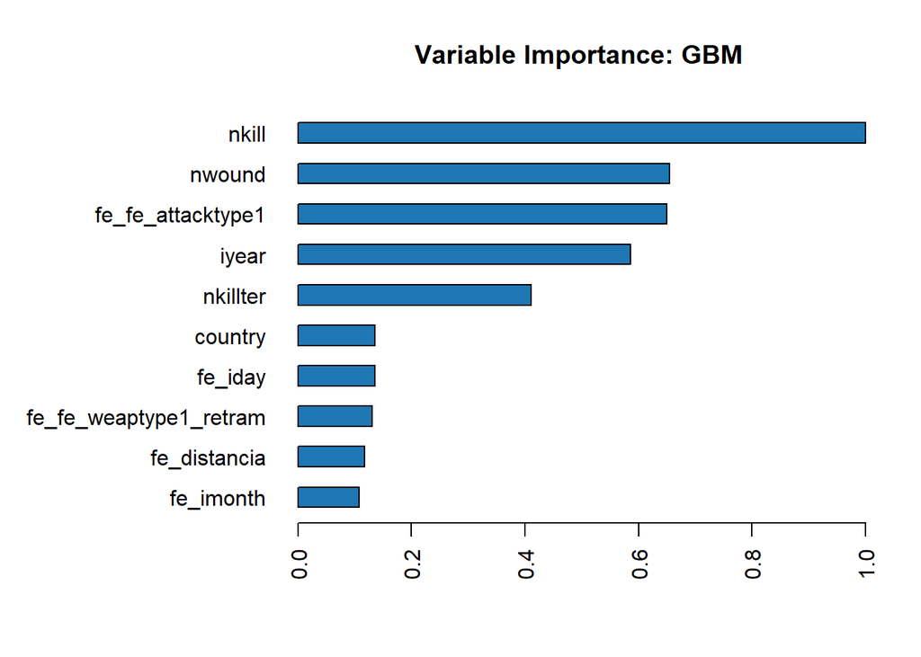

```r
h2o.varimp_plot(modelo10_gbm_es1)
```

Las variables más importantes para este modelo son: **‘nikill’**, **‘nwound’** y **‘attacktype1’**, **‘iyear’** y **nkillter**, siendo **‘nkill’** la variable más influyente con diferencia.

### 5.3.2 Algoritmo ‘GBM’ para el escenario 2

A continuación, utilizo el mismo algoritmo anterior pero con los datos del escenario 2.

```r
#Fijo la semilla
set.seed(7)
#Entreno el modelo gbm para el escenario 1 con los datos de train
modelo11_gbm_es2 <- h2o.gbm(
  x = x_es2,
  y = y_es2,
  training_frame = train_es2_hex,
  validation_frame = valid_es2_hex,
  nfolds = 5, #Número de campos para la validación cruzada.
  keep_cross_validation_predictions = TRUE,
  keep_cross_validation_fold_assignment = TRUE,
  score_each_iteration = TRUE,
  score_tree_interval = 5, #Número de árboles tras los que se evalúa el modelo.
  fold_assignment = 'Modulo', #Forma determinista simple de dividir uniformemente el conjunto de datos.
  balance_classes = TRUE, #La variable objetivo no está balanceada por lo tanto balanceamos las clases.
  ntrees = 100, #Número de árboles
  max_depth = 15, #Profundidad máxima de los árboles(número de nodos)
  #Evitamos sobre ajuste
  stopping_tolerance = 0.01, #Porcentaje mínimo de mejora entre dos mediciones consecutivas
  stopping_rounds=3, #Número de mediciones consecutivas en las que no se debe superar el stopping_tolerance.
  stopping_metric="AUCPR",
  distribution = 'bernoulli',
  sample_rate = 0.8,#Porcentaje de observaciones aleatorias empleadas para el ajuste de cada árbol
  learn_rate = 0.001,#Cuanto más pequeño es el valor de learning rate, más lentamente aprende el modelo, se reduce el riesgo de overfitting.
  huber_alpha = 0.8, #Umbral entre la pérdida cuadrática y lineal.
  set.seed(7)
)
```

- **Resultados del modelo.**

```r
#Imprimimos las métricas del modelo en Train
set.seed(7)
print(modelo11_gbm_es2)
```

```
## Model Details:
## ==============
##
## H2OBinomialModel: gbm
## Model ID:  GBM_model_R_1632597003111_1411
## Model Summary:
##   number_of_trees number_of_internal_trees model_size_in_bytes min_depth
## 1               6                        6              260830        15
##   max_depth mean_depth min_leaves max_leaves mean_leaves
## 1        15   15.00000       2753       3774  3465.33330
##
##
## H2OBinomialMetrics: gbm
## ** Reported on training data. **
##
## MSE:  0.3987688
## RMSE:  0.6314814
## LogLoss:  1.145343
## Mean Per-Class Error:  0.09023355
## AUC:  0.9705619
## AUCPR:  0.9751443
## Gini:  0.9411237
## R^2:  -0.5950752
##
## Confusion Matrix (vertical: actual; across: predicted) for F1-optimal threshold:
##            No   Yes    Error           Rate
## No      95629  6319 0.061983   =6319/101948
## Yes     12084 89904 0.118485  =12084/101988
## Totals 107713 96223 0.090239  =18403/203936
##
## Maximum Metrics: Maximum metrics at their respective thresholds
##                         metric threshold         value idx
## 1                       max f1  0.886843      0.907154 183
## 2                       max f2  0.886278      0.923483 273
## 3                 max f0point5  0.887218      0.940914 132
## 4                 max accuracy  0.886931      0.910188 171
## 5                max precision  0.888071      1.000000   0
## 6                   max recall  0.885690      1.000000 393
## 7              max specificity  0.888071      1.000000   0
## 8             max absolute_mcc  0.886931      0.823638 171
```

[output cut: 121 more lines]

```
## f1                        0.95687324    0.9576442  0.9579429
## f2                         0.9715557   0.96992683   0.972102
## lift_top_group             1.0697871    1.0853612  1.0857126
## logloss                   0.35344753   0.35486805 0.35514233
## max_per_class_error        0.5446224    0.5003791  0.5240439
## mcc                       0.55083305   0.57287806 0.56901497
## mean_per_class_accuracy   0.71848726    0.7389564 0.72886616
## mean_per_class_error      0.28151277    0.2610436 0.27113387
## mse                       0.10073552   0.10127175 0.10137389
## pr_auc                     0.9836952   0.98335904 0.98375237
## precision                 0.93336445    0.9378502  0.9352393
## r2                      0.0026958964 0.0026850996 0.00266631
## recall                     0.9815969    0.9782918  0.9817762
## rmse                       0.3173886    0.3182322 0.31839266
## specificity               0.45537758    0.4996209 0.47595608
```

Con este modelo y teniendo en cuenta los **datos** del **escenario 2**, obtenemos un porcentaje del **‘AUCPR’** del **97.51%** en train y un **98.58%** con los **datos** de **validación**.

Si observamos las métricas obtenidas en la fase de validación cruzada, podemos ver que el **nivel** de **predicción medio** es del **98.36%**, con una **desviación típica** del **0.0001**. Por lo que, el nivel de predicción se **mantiene** en un **98%**.

- **Evaluación del modelo**

Evaluamos el modelo teniendo en cuenta los datos de test.

```r
set.seed(7)
h2o.performance(modelo11_gbm_es2, newdata = test_es2_hex)
```

```
## H2OBinomialMetrics: gbm
##
## MSE:  0.1019997
## RMSE:  0.319374
## LogLoss:  0.3568104
## Mean Per-Class Error:  0.2699835
## AUC:  0.9087762
## AUCPR:  0.9828234
## Gini:  0.8175525
## R^2:  0.002625399
##
## Confusion Matrix (vertical: actual; across: predicted) for F1-optimal threshold:
##          No   Yes    Error         Rate
## No     2119  2303 0.520805   =2303/4422
## Yes     648 33169 0.019162   =648/33817
## Totals 2767 35472 0.077173  =2951/38239
##
## Maximum Metrics: Maximum metrics at their respective thresholds
##                         metric threshold        value idx
## 1                       max f1  0.885959     0.957410 353
## 2                       max f2  0.885748     0.978052 388
## 3                 max f0point5  0.886402     0.951933 291
## 4                 max accuracy  0.885968     0.922827 352
## 5                max precision  0.888066     0.991404   1
## 6                   max recall  0.885669     1.000000 399
## 7              max specificity  0.888071     0.969019   0
## 8             max absolute_mcc  0.886246     0.577562 312
## 9   max min_per_class_accuracy  0.887017     0.830884 196
## 10 max mean_per_class_accuracy  0.887009     0.831368 197
## 11                     max tns  0.888071  4285.000000   0
## 12                     max fns  0.888071 18196.000000   0
## 13                     max fps  0.885669  4422.000000 399
## 14                     max tps  0.885669 33817.000000 399
## 15                     max tnr  0.888071     0.969019   0
## 16                     max fnr  0.888071     0.538073   0
## 17                     max fpr  0.885669     1.000000 399
## 18                     max tpr  0.885669     1.000000 399
##
## Gains/Lift Table: Extract with `h2o.gainsLift(<model>, <data>)` or `h2o.gainsLift(<model>, valid=<T/F>, xval=<T/F>)`
```

Vemos como la precisión del modelo se sitúa en los **datos** de **test** en torno al **98.28%** (al igual que con los datos de validación), lo que indica que el modelo generaliza bien, y además, obtenemos una **bondad de ajuste** bastante **bueno**.

- **Matriz de confusión.**

```r
#Obtengo la matriz de confusión en test
h2o.confusionMatrix(modelo11_gbm_es2, newdata = test_es2_hex, metric = 'accuracy')
```

```
## Confusion Matrix (vertical: actual; across: predicted)  for max accuracy @ threshold = 0.885967938481439:
##          No   Yes    Error         Rate
## No     2161  2261 0.511307   =2261/4422
## Yes     708 33109 0.020936   =708/33817
## Totals 2869 35370 0.077643   =2969/38239
```

Es decir, tenemos una **capacidad de reconocer** los **atentados exitosos** del **93.60%** (Recall-‘Yes’: Sensibildad) y una capacidad de clasificar lo atentados **no exitosos** del **75.32%** (Recall - ’No: Especifidad). Un porcentaje **bastante bueno**.

Esto se ve reflejado en la **capacidad media** de reconocer los casos correctamente , **tanto exitosos** como **no exitosos**, es del **84.46%** (Balanced Accuracy: Media de los ‘Recall’ en las dos clases).

En cuanto a la **‘Precisión’** del modelo, es decir, cuanto de confiable es el modelo en clasificar correctamente, tenemos que en los **casos exitosos**, el modelo tiene una precisión del **97.90%**. **Y** el nivel de precisión en los casos **no exitosos**, es del **49%**. No es un porcentaje muy alto, aunque sí es el **mayor** que hemos alcandado **por el momento**, sin contar el modelo generado por ‘automl’.

Si comparamos este modelo con el mismo pero con los datos del escenario 1, los datos son muy parecidos, con este modelo ganamos un poco más en precisión para reconocer los casos negativos, 49% (escenario 1: 46%).

- **Importancia de cada variable.**

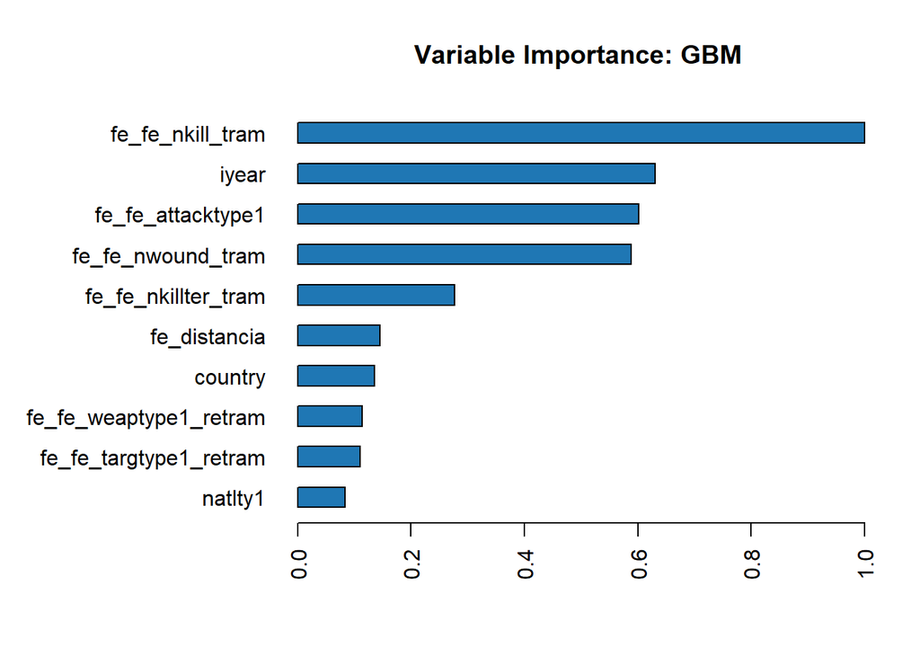

```r
h2o.varimp_plot(modelo11_gbm_es2)
```

Las variables más importantes en este caso, son: **‘nkill’**, **‘iyear’**, **‘nwound’** y **‘attacktype’**, siendo **‘nkill’** la **más influyente** con diferencia.

### 5.3.3 Algoritmo ‘GBM’ con grid-search para el escenario 1

```r
#Rangos de los parámetros que busco
hyper_params = list(
  max_depth = seq(5,10,15),
  sample_rate = seq(0.5,1,0.01),#Porcentaje de observaciones aleatorias empleadas para el ajuste de cada árbol
  col_sample_rate = seq(0.8,1,0.01)
)
search_criteria = list(
  strategy = "RandomDiscrete",
  max_models = 100,
  stopping_rounds = 5,
  stopping_metric = "AUCPR",
  stopping_tolerance = 0.0053
)

#Fijo la semilla
set.seed(7)

 grid_gbm <- h2o.grid(
  hyper_params = hyper_params,
  search_criteria = search_criteria,
  algorithm = "gbm",
  grid_id = "gbm_grid",
  x = x_es1,
  y = y_es1,
  training_frame = train_es1_hex,
  validation_frame = valid_es1_hex,
  nfolds = 5, #Número de campos para la validación cruzada.
  keep_cross_validation_predictions = TRUE,
  keep_cross_validation_fold_assignment = TRUE,
  score_each_iteration = TRUE,
  score_tree_interval = 5, #Número de árboles tras los que se evalúa el modelo.
  fold_assignment = 'Modulo', #Forma determinista simple de dividir uniformemente el conjunto de datos.
  balance_classes = TRUE, #La variable objetivo no está balanceada por lo tanto balanceamos las clases.
  ntrees = 100, #Número de árboles
  learn_rate = 0.001,#Cuanto más pequeño es el valor de learning rate, más lentamente aprende el modelo, se reduce el riesgo de overfitting.
  distribution = 'bernoulli',
  huber_alpha = 0.8, #Umbral entre la pérdida cuadrática y lineal.
  seed = 7
)
```

Selecciono el modelo que ha obtenido un mayor porcentaje de AUCPR:

```r
gbm_grid_ganador_es1 <- h2o.getGrid(grid_id = "gbm_grid",
                             sort_by = "AUCPR",
                             decreasing = TRUE)
print(gbm_grid_ganador_es1)
```

```
## H2O Grid Details
## ================
##
## Grid ID: gbm_grid
## Used hyper parameters:
##   -  col_sample_rate
##   -  max_depth
##   -  sample_rate
## Number of models: 11
## Number of failed models: 0
##
## Hyper-Parameter Search Summary: ordered by decreasing AUCPR
##    col_sample_rate max_depth sample_rate         model_ids              aucpr
## 1             0.81         5        0.52  gbm_grid_model_11 0.9798593079747002
## 2             0.93         5        0.62  gbm_grid_model_4 0.9791130348343097
## 3              0.8         5        0.72 gbm_grid_model_5 0.9790947186372637
## 4             0.84         5        0.97 gbm_grid_model_10 0.9784609612783386
## 5             0.85         5        0.88  gbm_grid_model_6 0.9784042314520368
## 6             0.92         5        0.85  gbm_grid_model_8 0.9783485033915457
## 7             0.91         5        0.91  gbm_grid_model_2 0.9782068648029455
## 8             0.98         5        0.78  gbm_grid_model_3  0.977973421931751
## 9             0.96         5        0.86  gbm_grid_model_7 0.9778193434865325
## 10            0.95         5        0.89  gbm_grid_model_1 0.9775704982857909
## 11            0.95         5        0.92  gbm_grid_model_9 0.9775019019008345
```

De los once modelos que se han generado con los parámetros indicados. Me quedaré con el que ha obtenido mayor valor en aucpr, el modelo gbm_grid_model_11, con un 97.98%.

Estos parámetros son:

- col_sample_rate: 0.81
- max_depth: 5
- sample_rate: 0.52

Con el fin de ahorrar tiempo de computación, incluiré estos parámetros manualmente en el algoritmo.

```r
#Me quedo con el modelo de mayor AUCPR
#modelo12_gbm_grid_es1_id <- grid_gbm@model_ids[[1]]
#modelo12_gbm_grid_es1 <- h2o.getModel(modelo12_gbm_grid_es1_id)
#Fijo la semilla
set.seed(7)
#Entreno el modelo gbm para el escenario 1 con los datos de train
modelo12_gbm_grid_es1 <- h2o.gbm(
  x = x_es1,
  y = y_es1,
  training_frame = train_es1_hex,
  validation_frame = valid_es1_hex,
  nfolds = 5, #Número de campos para la validación cruzada.
  keep_cross_validation_predictions = TRUE,
  keep_cross_validation_fold_assignment = TRUE,
  score_each_iteration = TRUE,
  score_tree_interval = 5, #Número de árboles tras los que se evalúa el modelo.
  fold_assignment = 'Modulo', #Forma determinista simple de dividir uniformemente el conjunto de datos.
  balance_classes = TRUE, #La variable objetivo no está balanceada por lo tanto balanceamos las clases.
  ntrees = 100, #Número de árboles
  #Evitamos sobre ajuste
  stopping_tolerance = 0.01, #Porcentaje mínimo de mejora entre dos mediciones consecutivas
  stopping_rounds=3, #Número de mediciones consecutivas en las que no se debe superar el stopping_tolerance.
  stopping_metric="AUCPR",
  distribution = 'bernoulli',
  learn_rate = 0.001,#Cuanto más pequeño es el valor de learning rate, más lentamente aprende el modelo, se reduce el riesgo de overfitting.
  huber_alpha = 0.8, #Umbral entre la pérdida cuadrática y lineal.
  max_depth = 5,
  sample_rate = 0.52,#Porcentaje de observaciones aleatorias empleadas para el ajuste de cada árbol
  col_sample_rate = 0.81,
  set.seed(7)
)
```

- **Resultados del modelo.**

```r
#Imprimimos las métricas del modelo en Train
set.seed(7)
print(modelo12_gbm_grid_es1)
```

```
## Model Details:
## ==============
##
## H2OBinomialModel: gbm
## Model ID:  GBM_model_R_1632597003111_14902
## Model Summary:
##   number_of_trees number_of_internal_trees model_size_in_bytes min_depth
## 1               6                        6                2760         5
##   max_depth mean_depth min_leaves max_leaves mean_leaves
## 1         5    5.00000         32         32    32.00000
##
##
## H2OBinomialMetrics: gbm
## ** Reported on training data. **
##
## MSE:  0.3992261
## RMSE:  0.6318434
## LogLoss:  1.147505
## Mean Per-Class Error:  0.2234544
## AUC:  0.8712028
## AUCPR:  0.8743318
## Gini:  0.7424057
## R^2:  -0.5969046
##
## Confusion Matrix (vertical: actual; across: predicted) for F1-optimal threshold:
##           No    Yes    Error           Rate
## No     65683  36290 0.355879  =36290/101973
## Yes     9284  92704 0.091030   =9284/101988
## Totals 74967 128994 0.223445  =45574/203961
##
## Maximum Metrics: Maximum metrics at their respective thresholds
##                         metric threshold         value idx
## 1                       max f1  0.886411      0.802695 328
## 2                       max f2  0.886296      0.876319 348
## 3                 max f0point5  0.886954      0.808729 227
## 4                 max accuracy  0.886721      0.777232 271
## 5                max precision  0.887956      0.996242   1
## 6                   max recall  0.885764      1.000000 399
## 7              max specificity  0.887963      0.999922   0
## 8             max absolute_mcc  0.886411      0.573580 328
```

[output cut: 121 more lines]

```
## f1                        0.95018387  0.94905865   0.94791764
## f2                        0.97685593    0.974817    0.9756391
## lift_top_group             1.1286745   1.1295614    1.1297278
## logloss                    0.3539764   0.3554113   0.35571006
## max_per_class_error        0.7761251   0.7668688    0.8046195
## mcc                        0.4118717   0.4022163    0.3757256
## mean_per_class_accuracy      0.60968  0.61295575   0.59520966
## mean_per_class_error         0.39032  0.38704425   0.40479034
## mse                       0.10084137  0.10138038   0.10148735
## pr_auc                     0.9777183   0.9790546    0.9761603
## precision                  0.9088262   0.9090255    0.9050576
## r2                      0.0016479424  0.00161533 0.0015499728
## recall                     0.9954851   0.9927803    0.9950388
## rmse                       0.3175553  0.31840286    0.3185708
## specificity               0.22387491  0.23313116   0.19538054
```

Con este modelo obtenemos un porcentaje de **‘AUCPR’** del **87.43%** en los datos de train y un **98%** con los **datos** de **validación**.

Si observamos las métricas obtenidas en la fase de validación cruzada, podemos ver que el **nivel** de **predicción medio** es del **97.89%**, con una **desviación típica** del **0.0006**.

- **Evaluación del modelo**

Evaluamos el modelo teniendo en cuenta los datos de test.

```r
set.seed(7)
h2o.performance(modelo12_gbm_grid_es1, newdata = test_es1_hex)
```

```
## H2OBinomialMetrics: gbm
##
## MSE:  0.1021084
## RMSE:  0.3195441
## LogLoss:  0.3573521
## Mean Per-Class Error:  0.4006322
## AUC:  0.8665486
## AUCPR:  0.9783424
## Gini:  0.7330972
## R^2:  0.00156288
##
## Confusion Matrix (vertical: actual; across: predicted) for F1-optimal threshold:
##          No   Yes    Error         Rate
## No      903  3519 0.795794   =3519/4422
## Yes     185 33632 0.005471   =185/33817
## Totals 1088 37151 0.096864  =3704/38239
##
## Maximum Metrics: Maximum metrics at their respective thresholds
##                         metric threshold        value idx
## 1                       max f1  0.886123     0.947807 377
## 2                       max f2  0.886015     0.976691 388
## 3                 max f0point5  0.886404     0.941219 337
## 4                 max accuracy  0.886123     0.903136 377
## 5                max precision  0.887941     0.998102   3
## 6                   max recall  0.885810     1.000000 398
## 7              max specificity  0.887963     0.999548   0
## 8             max absolute_mcc  0.886392     0.480048 340
## 9   max min_per_class_accuracy  0.886813     0.685889 269
## 10 max mean_per_class_accuracy  0.886817     0.772339 268
## 11                     max tns  0.887963  4420.000000   0
## 12                     max fns  0.887963 33191.000000   0
## 13                     max fps  0.885764  4422.000000 399
## 14                     max tps  0.885810 33817.000000 398
## 15                     max tnr  0.887963     0.999548   0
## 16                     max fnr  0.887963     0.981489   0
## 17                     max fpr  0.885764     1.000000 399
## 18                     max tpr  0.885810     1.000000 398
##
## Gains/Lift Table: Extract with `h2o.gainsLift(<model>, <data>)` or `h2o.gainsLift(<model>, valid=<T/F>, xval=<T/F>)`
```

Vemos como la precisión del modelo se sitúa en los **datos** de **test** en un **97.83%** (al mismo nivel que con los datos de validación: 98%, lo que indica que el modelo generaliza bien.

- **Matriz de confusión.**

```r
#Obtengo la matriz de confusión en test
h2o.confusionMatrix(modelo12_gbm_grid_es1, newdata = test_es1_hex, metric = 'accuracy')
```

```
## Confusion Matrix (vertical: actual; across: predicted)  for max accuracy @ threshold = 0.886123332411426:
##          No   Yes    Error         Rate
## No      907  3515 0.794889   =3515/4422
## Yes     203 33614 0.006003   =203/33817
## Totals 1110 37129 0.097231  =3718/38239
```

Es decir, tenemos una **capacidad de reconocer** los **atentados exitosos** del **90.53%** (Recall-‘Yes’: Sensibildad) y una capacidad de clasificar lo atentados **no exitosos** del **81.71%** (Recall - ’No: Especifidad). Un porcentaje **bueno**.

Esto se ve reflejado en la **capacidad media** de reconocer los casos correctamente , **tanto exitosos** como **no exitosos**, es del **86.12%** (Balanced Accuracy: Media de los ‘Recall’ en las dos clases).

En cuanto a la **‘Precisión’** del modelo, es decir, cuanto de confiable es el modelo en clasificar correctamente, tenemos que en los **casos exitosos**, el modelo tiene una precisión del **99.39%**. **Y** el nivel de precisión en los casos **no exitosos**, es del **20.51%**. Es un porcentaje **muy bajo**.

- **Importancia de cada variable.**

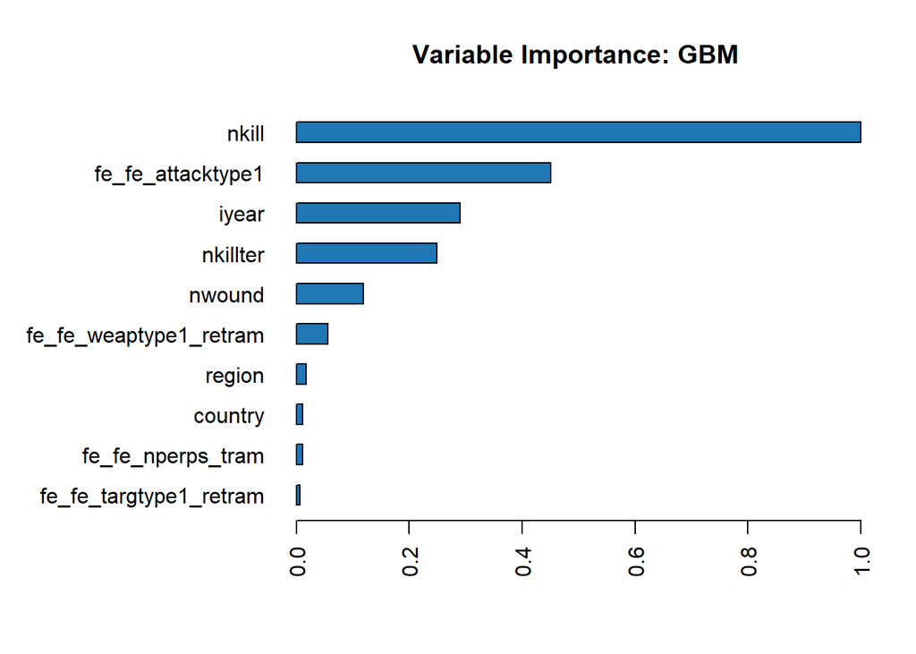

```r
h2o.varimp_plot(modelo12_gbm_grid_es1)
```

### 5.3.4 Algoritmo ‘GBM’ con grid-search para el escenario 2

Ahora realizaré un grid-research sobre el mismo algortimo anterior, pero con los datos del escenario 2.

```r
#Rangos de los parámetros que busco
hyper_params = list(
  max_depth = seq(5,20,30),
  sample_rate = seq(0.5,1,0.01),#Porcentaje de observaciones aleatorias empleadas para el ajuste de cada árbol
  col_sample_rate = seq(0.8,1,0.01)
)
search_criteria = list(
  strategy = "RandomDiscrete",
  max_models = 100,
  stopping_rounds = 5,
  stopping_metric = "AUCPR",
  stopping_tolerance = 0.0053
)

#Fijo la semilla
set.seed(7)

grid_gbm_es2 <- h2o.grid(
  hyper_params = hyper_params,
  search_criteria = search_criteria,
  algorithm = "gbm",
  grid_id = "gbm_grid_es2",
  x = x_es2,
  y = y_es2,
  training_frame = train_es2_hex,
  validation_frame = valid_es2_hex,
  nfolds = 5, #Número de campos para la validación cruzada.
  keep_cross_validation_predictions = TRUE,
  keep_cross_validation_fold_assignment = TRUE,
  score_each_iteration = TRUE,
  score_tree_interval = 5, #Número de árboles tras los que se evalúa el modelo.
  fold_assignment = 'Modulo', #Forma determinista simple de dividir uniformemente el conjunto de datos.
  balance_classes = TRUE, #La variable objetivo no está balanceada por lo tanto balanceamos las clases.
  ntrees = 100, #Número de árboles
  learn_rate = 0.001,#Cuanto más pequeño es el valor de learning rate, más lentamente aprende el modelo, se reduce el riesgo de overfitting.
  distribution = 'bernoulli',
  huber_alpha = 0.8, #Umbral entre la pérdida cuadrática y lineal.
  seed = 7
)
```

Selecciono el modelo que ha obtenido un mayor porcentaje de AUCPR:

```r
set.seed(7)
gbm_grid_ganador_es2 <- h2o.getGrid(grid_id = "gbm_grid_es2",
                             sort_by = "AUCPR",
                             decreasing = TRUE)
print(gbm_grid_ganador_es2)
```

```
## H2O Grid Details
## ================
##
## Grid ID: gbm_grid_es2
## Used hyper parameters:
##   -  col_sample_rate
##   -  max_depth
##   -  sample_rate
## Number of models: 11
## Number of failed models: 0
##
## Hyper-Parameter Search Summary: ordered by decreasing AUCPR
##    col_sample_rate max_depth sample_rate             model_ids
## 1             0.83         5        0.75  gbm_grid_es2_model_5
## 2             0.83         5        0.64 gbm_grid_es2_model_11
## 3             0.89         5        0.55  gbm_grid_es2_model_3
## 4             0.89         5        0.74 gbm_grid_es2_model_10
## 5             0.86         5        0.94  gbm_grid_es2_model_7
## 6             0.86         5        0.78  gbm_grid_es2_model_6
## 7              0.9         5        0.63  gbm_grid_es2_model_2
## 8             0.91         5        0.67  gbm_grid_es2_model_8
## 9             0.93         5        0.65  gbm_grid_es2_model_9
## 10            0.95         5        0.57  gbm_grid_es2_model_4
## 11             1.0         5        0.59  gbm_grid_es2_model_1
##                 aucpr
## 1  0.9837587316954535
## 2  0.9837428380776616
## 3  0.9833837520158705
## 4  0.9833583568229183
## 5  0.9833553823031354
## 6   0.983341846312537
## 7   0.983252899771275
## 8  0.9832404120544048
## 9  0.9832397115615233
## 10  0.982681631984249
## 11 0.9822518408564717
```

De los once modelos que se han generado con los parámetros indicados. Me quedaré con el que ha obtenido mayor valor en aucpr, el modelo gbm_grid_es2_model_5, con un 98.37%.

Estos parámetros son:

- col_sample_rate: 0.83
- max_depth: 5
- sample_rate: 0.75

Con el fin de ahorrar tiempo de computación, incluiré estos parámetros manualmente en el algoritmo.

```r
#Me quedo con el modelo de mayor AUCPR
#modelo13_gbm_grid_es2_id <- grid_gbm_es2@model_ids[[1]]
#modelo13_gbm_grid_es2 <- h2o.getModel(modelo13_gbm_grid_es2_id)
#Fijo la semilla
set.seed(7)
#Entreno el modelo gbm para el escenario 1 con los datos de train
modelo13_gbm_grid_es2 <- h2o.gbm(
  x = x_es2,
  y = y_es2,
  training_frame = train_es2_hex,
  validation_frame = valid_es2_hex,
  nfolds = 5, #Número de campos para la validación cruzada.
  keep_cross_validation_predictions = TRUE,
  keep_cross_validation_fold_assignment = TRUE,
  score_each_iteration = TRUE,
  score_tree_interval = 5, #Número de árboles tras los que se evalúa el modelo.
  fold_assignment = 'Modulo', #Forma determinista simple de dividir uniformemente el conjunto de datos.
  balance_classes = TRUE, #La variable objetivo no está balanceada por lo tanto balanceamos las clases.
  ntrees = 100, #Número de árboles
  #Evitamos sobre ajuste
  stopping_tolerance = 0.01, #Porcentaje mínimo de mejora entre dos mediciones consecutivas
  stopping_rounds=3, #Número de mediciones consecutivas en las que no se debe superar el stopping_tolerance.
  stopping_metric="AUCPR",
  distribution = 'bernoulli',
  learn_rate = 0.001,#Cuanto más pequeño es el valor de learning rate, más lentamente aprende el modelo, se reduce el riesgo de overfitting.
  huber_alpha = 0.8, #Umbral entre la pérdida cuadrática y lineal.
  max_depth = 5,
  sample_rate = 0.75,#Porcentaje de observaciones aleatorias empleadas para el ajuste de cada árbol
  col_sample_rate = 0.83,
  set.seed(7)
)
```

- **Resultados del modelo.**

```r
#Imprimimos las métricas del modelo en Train
print(modelo13_gbm_grid_es2)
```

```
## Model Details:
## ==============
##
## H2OBinomialModel: gbm
## Model ID:  GBM_model_R_1632597003111_28393
## Model Summary:
##   number_of_trees number_of_internal_trees model_size_in_bytes min_depth
## 1               6                        6                2759         5
##   max_depth mean_depth min_leaves max_leaves mean_leaves
## 1         5    5.00000         32         32    32.00000
##
##
## H2OBinomialMetrics: gbm
## ** Reported on training data. **
##
## MSE:  0.3992767
## RMSE:  0.6318835
## LogLoss:  1.147394
## Mean Per-Class Error:  0.1796508
## AUC:  0.8971818
## AUCPR:  0.8948559
## Gini:  0.7943636
## R^2:  -0.5971072
##
## Confusion Matrix (vertical: actual; across: predicted) for F1-optimal threshold:
##           No    Yes    Error           Rate
## No     80234  21822 0.213824  =21822/102056
## Yes    14837  87151 0.145478  =14837/101988
## Totals 95071 108973 0.179662  =36659/204044
##
## Maximum Metrics: Maximum metrics at their respective thresholds
##                         metric threshold         value idx
## 1                       max f1  0.886828      0.826229 288
## 2                       max f2  0.886103      0.877480 363
## 3                 max f0point5  0.887284      0.844400 195
## 4                 max accuracy  0.886891      0.821710 277
## 5                max precision  0.888020      1.000000   0
## 6                   max recall  0.885692      1.000000 398
## 7              max specificity  0.888020      1.000000   0
## 8             max absolute_mcc  0.886891      0.644592 277
```

[output cut: 121 more lines]

```
## f1                         0.9503083     0.950031   0.94910395
## f2                         0.9675167    0.9675072     0.974665
## lift_top_group             1.1286745    1.1295614    1.1297278
## logloss                   0.35376027    0.3551966   0.35547128
## max_per_class_error       0.63539284   0.63722515   0.76258993
## mcc                        0.4607471   0.46021995   0.40492162
## mean_per_class_accuracy    0.6719733    0.6711472    0.6149473
## mean_per_class_error      0.32802668   0.32885274    0.3850527
## mse                      0.100798056  0.101337366   0.10143958
## pr_auc                     0.9837445     0.983566    0.9841998
## precision                 0.92294884    0.9222659   0.90935683
## r2                      0.0020767828 0.0020389082 0.0020200245
## recall                     0.9793395   0.97951967    0.9924845
## rmse                       0.3174871    0.3183353    0.3184958
## specificity               0.36460716   0.36277482   0.23741007
```

Con este modelo obtenemos un porcentaje de **‘AUCPR’** del **89.48%** en los datos de train y un **98.38%** con los **datos** de **validación**.

Si observamos las métricas obtenidas en la fase de validación cruzada, podemos ver que el **nivel** de **predicción medio** es del **98.30%**, con una **desviación típica** del **0.0004**. Por lo que, el nivel de predicción se **mantiene** en un **98%**.

- **Evaluación del modelo**

Evaluamos el modelo teniendo en cuenta los datos de test.

```r
h2o.performance(modelo13_gbm_grid_es2, newdata = test_es2_hex)
```

```
## H2OBinomialMetrics: gbm
##
## MSE:  0.1020659
## RMSE:  0.3194775
## LogLoss:  0.3571404
## Mean Per-Class Error:  0.3837445
## AUC:  0.8926696
## AUCPR:  0.9814116
## Gini:  0.7853393
## R^2:  0.001978932
##
## Confusion Matrix (vertical: actual; across: predicted) for F1-optimal threshold:
##          No   Yes    Error         Rate
## No     1067  3355 0.758706   =3355/4422
## Yes     297 33520 0.008783   =297/33817
## Totals 1364 36875 0.095505  =3652/38239
##
## Maximum Metrics: Maximum metrics at their respective thresholds
##                         metric threshold        value idx
## 1                       max f1  0.885998     0.948339 374
## 2                       max f2  0.885830     0.976781 385
## 3                 max f0point5  0.886606     0.944841 330
## 4                 max accuracy  0.886107     0.906666 366
## 5                max precision  0.888020     1.000000   0
## 6                   max recall  0.885692     1.000000 398
## 7              max specificity  0.888020     1.000000   0
## 8             max absolute_mcc  0.886606     0.503969 330
## 9   max min_per_class_accuracy  0.886831     0.795428 299
## 10 max mean_per_class_accuracy  0.886883     0.819680 290
## 11                     max tns  0.888020  4422.000000   0
## 12                     max fns  0.888020 33688.000000   0
## 13                     max fps  0.885687  4422.000000 399
## 14                     max tps  0.885692 33817.000000 398
## 15                     max tnr  0.888020     1.000000   0
## 16                     max fnr  0.888020     0.996185   0
## 17                     max fpr  0.885687     1.000000 399
## 18                     max tpr  0.885692     1.000000 398
##
## Gains/Lift Table: Extract with `h2o.gainsLift(<model>, <data>)` or `h2o.gainsLift(<model>, valid=<T/F>, xval=<T/F>)`
```

Vemos como la precisión del modelo se sitúa en los **datos** de **test** en un **98.14%** (porcentaje un poco más alto que en train: 89.48%, e igual que en validación: 98.38%), lo que indica que el modelo generaliza bien, aunque es posible que sobre alguna variable.

- **Matriz de confusión.**

```r
#Obtengo la matriz de confusión en test
h2o.confusionMatrix(modelo13_gbm_grid_es2, newdata = test_es2_hex, metric = 'accuracy')
```

```
## Confusion Matrix (vertical: actual; across: predicted)  for max accuracy @ threshold = 0.886106874683704:
##          No   Yes    Error         Rate
## No     933  3489  0.789009  =3489/4422
## Yes    210  33607 0.006210  =210/33817
## Totals 1143 37096 0.096734  =3699/38239
```

Es decir, tenemos una **capacidad de reconocer** los **atentados exitosos** del **90.59%** (Recall-‘Yes’: Sensibildad) y una capacidad de clasificar lo atentados **no exitosos** del **81.62%** (Recall - ’No: Especifidad). Un porcentaje **un poco bajo**.

Esto se ve reflejado en la **capacidad media** de reconocer los casos correctamente , **tanto exitosos** como **no exitosos**, es del **86.10%** (Balanced Accuracy: Media de los ‘Recall’ en las dos clases).

En cuanto a la **‘Precisión’** del modelo, es decir, cuanto de confiable es el modelo en clasificar correctamente, tenemos que en los **casos exitosos**, el modelo tiene una precisión del **99.37%**. **Y** el nivel de precisión en los casos **no exitosos**, es del **21%**. Es un porcentaje bajo.

- **Importancia de cada variable.**

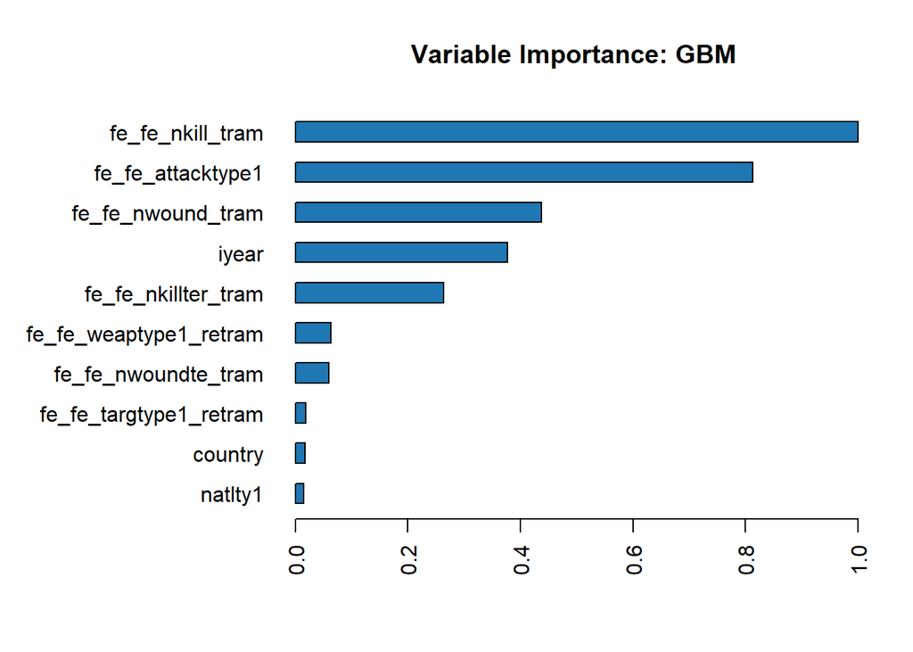

```r
h2o.varimp_plot(modelo13_gbm_grid_es2)
```

Las variables más importantes para el modelo son: **‘nkill’**, **‘attacktype1’** y **‘nwound’**, siendo **‘nkill’** la **más influyente** con diferencia.

## 5.4 Algoritmo ‘Random Forest’

Random Forest es un modelo de aprendizaje **supervisado** para **clasificación** (aunque también puede usarse para regresión).

Un modelo Random Forest está **formado** por un **conjunto** (ensemble) de **árboles de decisión individuales**. Esto implica que cada árbol se entrena con unos datos ligeramente distintos. En cada árbol individual, las observaciones se van distribuyendo por bifurcaciones (nodos) generando la estructura del árbol hasta alcanzar un nodo terminal. La **predicción** de una **nueva observación** se obtiene **agregando** las **predicciones** de **todos** los **árboles** individuales que forman el modelo.

- **Ventajas**:
  - Funciona bien, aún sin ajuste de hiperparámetros.
  - Una de las salidas del modelo es la importancia de variables.
- **Incovenientes**:
  - En algunos datos de entrada “particulares” random forest también puede caer en overfitting.

### 5.4.1 Algoritmo ‘Random Forest’ para el escenario 1

Utilizo los mismos parámetros que los utilizados en el ‘GBM’.

```r
#Fijo la semilla
set.seed(7)
#Entreno el modelo gbm para el escenario 1 con los datos de train
modelo14_rf_es1 <- h2o.randomForest(
  x = x_es1,
  y = y_es1,
  training_frame = train_es1_hex,
  validation_frame = valid_es1_hex,
  nfolds = 5, #Número de campos para la validación cruzada.
  keep_cross_validation_predictions = TRUE,
  keep_cross_validation_fold_assignment = TRUE,
  score_each_iteration = TRUE,
  score_tree_interval = 5, #Número de árboles tras los que se evalúa el modelo.
  fold_assignment = 'Modulo', #Forma determinista simple de dividir uniformemente el conjunto de datos.
  balance_classes = TRUE, #La variable objetivo no está balanceada por lo tanto balanceamos las clases.
  ntrees = 100, #Número de árboles
  max_depth = 15, #Profundidad máxima de los árboles(número de nodos)
  #Evitamos sobre ajuste
  stopping_tolerance = 0.01, #Porcentaje mínimo de mejora entre dos mediciones consecutivas
  stopping_rounds=3, #Número de mediciones consecutivas en las que no se debe superar el stopping_tolerance.
  stopping_metric="AUCPR",
  distribution = 'bernoulli',
  sample_rate = 0.8,#Porcentaje de observaciones aleatorias empleadas para el ajuste de cada árbol
  seed = 7
)
```

- **Resultados del modelo.**

```r
#Imprimimos las métricas del modelo en Train
print(modelo14_rf_es1)
```

```
## Model Details:
## ==============
##
## H2OBinomialModel: drf
## Model ID:  DRF_model_R_1632597003111_28486
## Model Summary:
##   number_of_trees number_of_internal_trees model_size_in_bytes min_depth
## 1               7                        7              295826        15
##   max_depth mean_depth min_leaves max_leaves mean_leaves
## 1        15   15.00000       2557       3952  3361.57150
##
##
## H2OBinomialMetrics: drf
## ** Reported on training data. **
## ** Metrics reported on Out-Of-Bag training samples **
##
## MSE:  0.2026972
## RMSE:  0.4502191
## LogLoss:  0.6555153
## Mean Per-Class Error:  0.1462152
## AUC:  0.9297503
## AUCPR:  0.940073
## Gini:  0.8595006
## R^2:  0.1892111
##
## Confusion Matrix (vertical: actual; across: predicted) for F1-optimal threshold:
##           No   Yes    Error           Rate
## No     68890 11395 0.141932   =11395/80285
## Yes    12090 68243 0.150499   =12090/80333
## Totals 80980 79638 0.146216  =23485/160618
##
## Maximum Metrics: Maximum metrics at their respective thresholds
##                         metric threshold        value idx
## 1                       max f1  0.870610     0.853192  86
## 2                       max f2  0.683515     0.888662 175
## 3                 max f0point5  0.933413     0.885155  47
## 4                 max accuracy  0.886838     0.856274  77
## 5                max precision  0.999990     1.000000   0
## 6                   max recall  0.000000     1.000000 399
## 7              max specificity  0.999990     1.000000   0
```

[output cut: 122 more lines]

```
## f1                       0.95354325  0.95522034  0.9542371
## f2                        0.9701797  0.97152764  0.9702551
## lift_top_group            1.1213168   1.1245677  1.1125872
## logloss                  0.24165118  0.23908697 0.25307748
## max_per_class_error      0.60030514   0.5777104  0.5808406
## mcc                      0.50298613  0.52829254 0.51876795
## mean_per_class_accuracy   0.6906459   0.7025008 0.70019764
## mean_per_class_error      0.3093541  0.29749918 0.29980236
## mse                       0.0704724 0.068817884 0.07097457
## pr_auc                   0.98296976   0.9824849  0.9805928
## precision                0.92704856   0.9292249 0.92868435
## r2                       0.30230758   0.3222878 0.30173996
## recall                    0.9815969  0.98271203 0.98123586
## rmse                     0.26546636  0.26233163 0.26641053
## specificity               0.3996949   0.4222896  0.4191594
```

Con este modelo obtenemos un porcentaje de **‘AUCPR’** del **94%** en los datos de train y un **98.22%** con los **datos** de **validación**.

Si observamos las métricas obtenidas en la fase de validación cruzada, podemos ver que el **nivel** de **predicción medio** es del **98.18%**, con una **desviación típica** del **0.001**. Por lo que, el nivel de predicción se **mantiene** en un **98%**.

- **Evaluación del modelo**

Evaluamos el modelo teniendo en cuenta los datos de test.

```r
h2o.performance(modelo14_rf_es1, newdata = test_es1_hex)
```

```
## H2OBinomialMetrics: drf
##
## MSE:  0.06952635
## RMSE:  0.2636785
## LogLoss:  0.2377835
## Mean Per-Class Error:  0.3058863
## AUC:  0.902347
## AUCPR:  0.9829361
## Gini:  0.8046939
## R^2:  0.3201569
##
## Confusion Matrix (vertical: actual; across: predicted) for F1-optimal threshold:
##          No   Yes    Error         Rate
## No     1785  2637 0.596336   =2637/4422
## Yes     522 33295 0.015436   =522/33817
## Totals 2307 35932 0.082612  =3159/38239
##
## Maximum Metrics: Maximum metrics at their respective thresholds
##                         metric threshold        value idx
## 1                       max f1  0.686472     0.954709 244
## 2                       max f2  0.419112     0.976457 326
## 3                 max f0point5  0.838826     0.950331 172
## 4                 max accuracy  0.686472     0.917388 244
## 5                max precision  0.998166     0.996117   3
## 6                   max recall  0.015430     1.000000 398
## 7              max specificity  0.999975     0.998643   0
## 8             max absolute_mcc  0.813838     0.565056 188
## 9   max min_per_class_accuracy  0.914538     0.823609 116
## 10 max mean_per_class_accuracy  0.906743     0.826217 123
## 11                     max tns  0.999975  4416.000000   0
## 12                     max fns  0.999975 32630.000000   0
## 13                     max fps  0.004586  4422.000000 399
## 14                     max tps  0.015430 33817.000000 398
## 15                     max tnr  0.999975     0.998643   0
## 16                     max fnr  0.999975     0.964899   0
## 17                     max fpr  0.004586     1.000000 399
## 18                     max tpr  0.015430     1.000000 398
##
## Gains/Lift Table: Extract with `h2o.gainsLift(<model>, <data>)` or `h2o.gainsLift(<model>, valid=<T/F>, xval=<T/F>)`
```

Vemos como la precisión del modelo se sitúa en los **datos** de **test** en un **98.29%** (porcentaje un poco más alto que en train: 94%, muy parecido en validación: 98.22), lo que indica que el modelo generaliza bien.

- **Matriz de confusión.**

```r
#Obtengo la matriz de confusión en test
h2o.confusionMatrix(modelo14_rf_es1, newdata = test_es1_hex, metric = 'accuracy')
```

```
## Confusion Matrix (vertical: actual; across: predicted)  for max accuracy @ threshold = 0.686472420429452:
##          No   Yes    Error         Rate
## No     1785  2637 0.596336   =2637/4422
## Yes     522 33295 0.015436   =522/33817
## Totals 2307 35932 0.082612  =3159/38239
```

Es decir, tenemos una **capacidad de reconocer** los **atentados exitosos** del **92.66%** (Recall-‘Yes’: Sensibildad) y una capacidad de clasificar lo atentados **no exitosos** del **77.37%** (Recall - ’No: Especifidad). Un porcentaje **bueno**.

Esto se ve reflejado en la **capacidad media** de reconocer los casos correctamente , **tanto exitosos** como **no exitosos**, es del **85%** (Balanced Accuracy: Media de los ‘Recall’ en las dos clases).

En cuanto a la **‘Precisión’** del modelo, es decir, cuanto de confiable es el modelo en clasificar correctamente, tenemos que en los **casos exitosos**, el modelo tiene una precisión del **98.45%**. **Y** el nivel de precisión en los casos **no exitosos**, es del **40.36%**. Es un porcentaje todavía bajo.

Con ester modelo, tenemos unas métricas un **poco** por **debajo** respecto a los modelos **‘GBM’** sin grid-research.

- **Importancia de cada variable.**

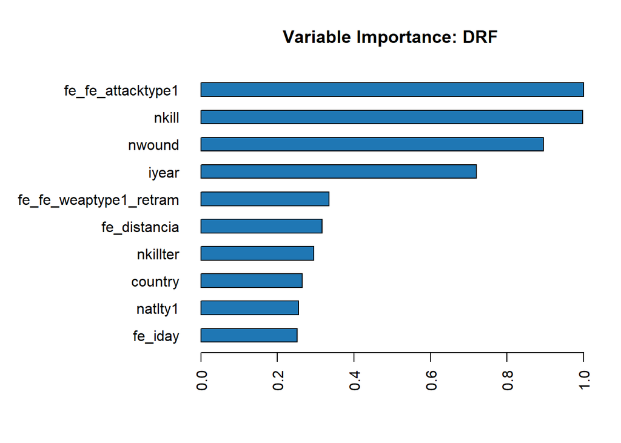

```r
h2o.varimp_plot(modelo14_rf_es1)
```

### 5.4.2 Algoritmo ‘Random Forest’ para el escenario 2

Utilizo el mismo algorimo anterior pero con los datos del segundo escenario.

```r
#Fijo la semilla
set.seed(7)
#Entreno el modelo gbm para el escenario 1 con los datos de train
modelo15_rf_es2 <- h2o.randomForest(
  x = x_es2,
  y = y_es2,
  training_frame = train_es2_hex,
  validation_frame = valid_es2_hex,
  nfolds = 5, #Número de campos para la validación cruzada.
  keep_cross_validation_predictions = TRUE,
  keep_cross_validation_fold_assignment = TRUE,
  score_each_iteration = TRUE,
  score_tree_interval = 5, #Número de árboles tras los que se evalúa el modelo.
  fold_assignment = 'Modulo', #Forma determinista simple de dividir uniformemente el conjunto de datos.
  balance_classes = TRUE, #La variable objetivo no está balanceada por lo tanto balanceamos las clases.
  ntrees = 100, #Número de árboles
  max_depth = 15, #Profundidad máxima de los árboles(número de nodos)
  #Evitamos sobre ajuste
  stopping_tolerance = 0.01, #Porcentaje mínimo de mejora entre dos mediciones consecutivas
  stopping_rounds=3, #Número de mediciones consecutivas en las que no se debe superar el stopping_tolerance.
  stopping_metric="AUCPR",
  distribution = 'bernoulli',
  sample_rate = 0.8,#Porcentaje de observaciones aleatorias empleadas para el ajuste de cada árbol
  seed = 7
)
```

- **Resultados del modelo.**

```r
#Imprimimos las métricas del modelo en Train
print(modelo15_rf_es2)
```

```
## Model Details:
## ==============
##
## H2OBinomialModel: drf
## Model ID:  DRF_model_R_1632597003111_28591
## Model Summary:
##   number_of_trees number_of_internal_trees model_size_in_bytes min_depth
## 1               7                        7              369504        15
##   max_depth mean_depth min_leaves max_leaves mean_leaves
## 1        15   15.00000       3653       4594  4211.57130
##
##
## H2OBinomialMetrics: drf
## ** Reported on training data. **
## ** Metrics reported on Out-Of-Bag training samples **
##
## MSE:  0.1622494
## RMSE:  0.4028019
## LogLoss:  0.5526869
## Mean Per-Class Error:  0.1151594
## AUC:  0.9508369
## AUCPR:  0.9600574
## Gini:  0.9016738
## R^2:  0.3510024
##
## Confusion Matrix (vertical: actual; across: predicted) for F1-optimal threshold:
##           No   Yes    Error           Rate
## No     73267  7018 0.087414    =7018/80285
## Yes    11480 68853 0.142905   =11480/80333
## Totals 84747 75871 0.115168  =18498/160618
##
## Maximum Metrics: Maximum metrics at their respective thresholds
##                         metric threshold        value idx
## 1                       max f1  0.871125     0.881578  78
## 2                       max f2  0.688840     0.903652 161
## 3                 max f0point5  0.933975     0.917302  45
## 4                 max accuracy  0.886773     0.886065  71
## 5                max precision  0.999994     1.000000   0
## 6                   max recall  0.000000     1.000000 399
## 7              max specificity  0.999994     1.000000   0
```

[output cut: 122 more lines]

```
## f1                      0.95477986  0.9570364  0.95558375
## f2                      0.97048974 0.97115237   0.9708115
## lift_top_group           1.1181865  1.1193175   1.1154599
## logloss                 0.25087643 0.25922206  0.27189136
## max_per_class_error       0.576659  0.5314632   0.5585006
## mcc                     0.52207386  0.5584564   0.5379118
## mean_per_class_accuracy 0.70229715  0.7246667  0.71136767
## mean_per_class_error    0.29770282 0.27533332  0.28863233
## mse                     0.06371321 0.06286755 0.064199194
## pr_auc                   0.9839077 0.98299253   0.9819695
## precision               0.92969733 0.93440014  0.93123865
## r2                      0.36922505 0.38088608   0.3683973
## recall                   0.9812534 0.98079664  0.98123586
## rmse                    0.25241476 0.25073403   0.2533756
## specificity             0.42334095 0.46853676  0.44149944
```

Con este modelo obtenemos un porcentaje de **‘AUCPR’** del **96%** en los datos de train y un **98.55%** con los **datos** de **validación**.

Si observamos las métricas obtenidas en la fase de validación cruzada, podemos ver que el **nivel** de **predicción medio** es del **98.28%**, con una **desviación típica** del **0.0007**. Por lo que, el nivel de predicción se **mantiene** en un **98%**.

- **Evaluación del modelo**

Evaluamos el modelo teniendo en cuenta los datos de test.

```r
h2o.performance(modelo15_rf_es2, newdata = test_es2_hex)
```

```
## H2OBinomialMetrics: drf
##
## MSE:  0.06345605
## RMSE:  0.2519049
## LogLoss:  0.2445088
## Mean Per-Class Error:  0.2816003
## AUC:  0.9086031
## AUCPR:  0.9837771
## Gini:  0.8172062
## R^2:  0.3795136
##
## Confusion Matrix (vertical: actual; across: predicted) for F1-optimal threshold:
##          No   Yes    Error         Rate
## No     2016  2406 0.544098   =2406/4422
## Yes     646 33171 0.019103   =646/33817
## Totals 2662 35577 0.079814  =3052/38239
##
## Maximum Metrics: Maximum metrics at their respective thresholds
##                         metric threshold        value idx
## 1                       max f1  0.636776     0.956019 239
## 2                       max f2  0.355735     0.977522 319
## 3                 max f0point5  0.822788     0.951229 158
## 4                 max accuracy  0.636776     0.920186 239
## 5                max precision  0.999648     0.993939   1
## 6                   max recall  0.000000     1.000000 399
## 7              max specificity  0.999975     0.992085   0
## 8             max absolute_mcc  0.770398     0.567447 185
## 9   max min_per_class_accuracy  0.917455     0.830973  95
## 10 max mean_per_class_accuracy  0.936507     0.831903  82
## 11                     max tns  0.999975  4387.000000   0
## 12                     max fns  0.999975 28851.000000   0
## 13                     max fps  0.000000  4422.000000 399
## 14                     max tps  0.000000 33817.000000 399
## 15                     max tnr  0.999975     0.992085   0
## 16                     max fnr  0.999975     0.853151   0
## 17                     max fpr  0.000000     1.000000 399
## 18                     max tpr  0.000000     1.000000 399
##
## Gains/Lift Table: Extract with `h2o.gainsLift(<model>, <data>)` or `h2o.gainsLift(<model>, valid=<T/F>, xval=<T/F>)`
```

Vemos como la precisión del modelo se sitúa en los **datos** de **test** en un **98.37%** (porcentaje parecido a los obtenidos en train y validación), lo que indica que el modelo generaliza bien.

- **Matriz de confusión.**

```r
#Obtengo la matriz de confusión en test
h2o.confusionMatrix(modelo15_rf_es2, newdata = test_es2_hex, metric = 'accuracy')
```

```
## Confusion Matrix (vertical: actual; across: predicted)  for max accuracy @ threshold = 0.636775554594682:
##          No   Yes    Error         Rate
## No     2016  2406 0.544098   =2406/4422
## Yes     646 33171 0.019103   =646/33817
## Totals 2662 35577 0.079814  =3052/38239
```

Si observamos la matriz de confusión, podemos ver que de los 2662 atentados que en realidad no son exitosos, el modelo ha sido capaz de reconocer a 2016 (hay 646 falsos positivos), de 35577 que son en realidad atentados exitosos, el modelo reconoce a 33171 (hay 2406 falsos negativos).

Es decir, tenemos una **capacidad de reconocer** los **atentados exitosos** del **93.23%** (Recall-‘Yes’: Sensibildad) y una capacidad de clasificar lo atentados **no exitosos** del **75.73%** (Recall - ’No: Especifidad). Un porcentaje **bueno**.

Esto se ve reflejado en la **capacidad media** de reconocer los casos correctamente , **tanto exitosos** como **no exitosos**, es del **84.48%** (Balanced Accuracy: Media de los ‘Recall’ en las dos clases).

En cuanto a la **‘Precisión’** del modelo, es decir, cuanto de confiable es el modelo en clasificar correctamente, tenemos que en los **casos exitosos**, el modelo tiene una precisión del **98%**. **Y** el nivel de precisión en los casos **no exitosos**, es del **45.59%**. Es un porcentaje todavía bajo.

Son unos valores un **poquito más altos** **que** los alcanzados con el mismo modelo, pero con los datos del **escenario 1**.

- **Importancia de cada variable.**

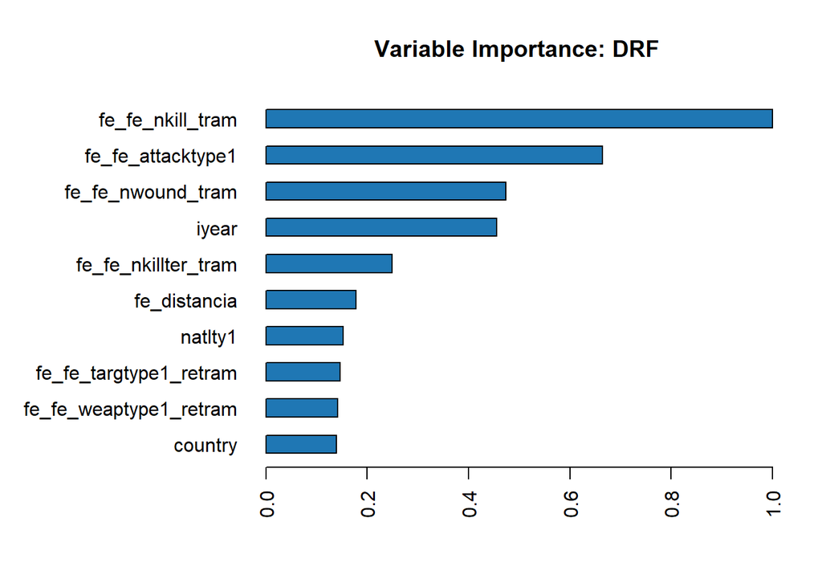

```r
h2o.varimp_plot(modelo15_rf_es2)
```

Las variables **más importantes** en este modelo, son: **‘nkill’**, **‘attacktype1’**, **‘nwound’** e **‘iyear’**, siendo ‘nkill’ la variable más influyente con diferencia.

### 5.4.3 Algoritmo ‘Random Forest’ con grid-research para el escenario 1

Una vez conocidos los hiperparámetros que optimizan el ‘AUCPR’, los incluiré directamente en el algoritmo, para ahorrar tiempo en computación.

```r
#Pongo el agoritmo comentado para ahorrar tiempo en ejecución
#Rangos de los parámetros que busco
#hyper_params = list(
 # max_depth = seq(8,14,1),
  #sample_rate = seq(0.5,1,0.01),
  #col_sample_rate_per_tree = seq(0.5,1,0.01),
  #col_sample_rate_change_per_level = seq(1.01,1.9,0.01),
  #min_split_improvement = c(1e-4, 1e-6, 1e-7)
#)
#search_criteria = list(
 # strategy = "RandomDiscrete",
  #max_models = 100,
  #seed = 7,
  #Evitamos el sobreajuste
  #stopping_rounds = 3,
  #stopping_metric = "AUTO",
  #stopping_tolerance = 0.01)

#Fijo la semilla
#set.seed(7)
#grid_rf_es1 <- h2o.grid(
 # hyper_params = hyper_params,
#  search_criteria = search_criteria,
 # algorithm = "randomForest",
  #grid_id = "rf_grid_es1",
  #x = x_es1,
  #y = y_es1,
  #training_frame = train_es1_hex,
  #validation_frame = valid_es1_hex,
  #nfolds = 5, #Número de campos para la validación cruzada.
  #keep_cross_validation_predictions = TRUE,
  #keep_cross_validation_fold_assignment = TRUE,
  #score_each_iteration = TRUE,
  #score_tree_interval = 5, #Número de árboles tras los que se evalúa el modelo.
  #fold_assignment = 'Modulo', #Forma determinista simple de dividir uniformemente    el conjunto de datos.
  #balance_classes = TRUE, #La variable objetivo no está balanceada por lo tanto      balanceamos las clases.
  #ntrees = 100, #Número de árboles
  #stopping_metric = 'AUTO',
  #seed = 7
#)
```

Selecciono el modelo que ha obtenido un mayor porcentaje de AUCPR:

```r
#rf_grid_ganador_es1 <- h2o.getGrid(grid_id = "rf_grid_es1",
 #                            sort_by = "AUCPR",
  #                           decreasing = TRUE)
#print(rf_grid_ganador_es1)
```

De los cien modelos que se han generado con los parámetros indicados. Me quedaré con el que ha obtenido mayor valor en aucpr, el modelo rf_grid_es1_model_48, con un 98.23%.

Los mejores hiperparámetros obtenidos son:

- col_sample_rate_change_per_level= 1.02,
- col_sample_rate_per_tree = 0.84,
- max_depth = 10,
- min_split_improvement = 1.0E-4,
- sample_rate = 0.74

```r
#Me quedo con el modelo de mayor AUCPR
#modelo16_rf_grid_es1_id <- grid_rf_es1@model_ids[[1]]
#modelo16_rf_grid_es1 <- h2o.getModel(modelo16_rf_grid_es1_id)
```

```r
#Para ahorrar en tiempo de computación incluiré los hiperparámetros obtenidos en el grid-reseach en el algoritmo directamente.
#Fijo la semilla
set.seed(7)
modelo16_rf_grid_es1 <- h2o.randomForest(
  x = x_es1,
  y = y_es1,
  training_frame = train_es1_hex,
  validation_frame = valid_es1_hex,
  nfolds = 5, #Número de campos para la validación cruzada.
  keep_cross_validation_predictions = TRUE,
  keep_cross_validation_fold_assignment = TRUE,
  score_each_iteration = TRUE,
  score_tree_interval = 5, #Número de árboles tras los que se evalúa el modelo.
  fold_assignment = 'Modulo', #Forma determinista simple de dividir uniformemente el conjunto de datos.
  balance_classes = TRUE, #La variable objetivo no está balanceada por lo tanto balanceamos las clases.
  ntrees = 100, #Número de árboles
  max_depth = 10, #Profundidad máxima de los árboles(número de nodos)
  #Evitamos sobre ajuste
  stopping_tolerance = 0.01, #Porcentaje mínimo de mejora entre dos mediciones consecutivas
  stopping_rounds=3, #Número de mediciones consecutivas en las que no se debe superar el stopping_tolerance.
  stopping_metric="AUCPR",
  distribution = 'bernoulli',
  sample_rate = 0.74,#Porcentaje de observaciones aleatorias empleadas para el ajuste de cada árbol
  col_sample_rate_per_tree = 0.84,
  col_sample_rate_change_per_level = 1.02,
  min_split_improvement = 1e-4,
  seed = 7
)
```

- **Resultados del modelo.**

```r
#Imprimimos las métricas del modelo en Train
set.seed(7)
print(modelo16_rf_grid_es1)
```

```
## Model Details:
## ==============
##
## H2OBinomialModel: drf
## Model ID:  DRF_model_R_1632597003111_28690
## Model Summary:
##   number_of_trees number_of_internal_trees model_size_in_bytes min_depth
## 1               7                        7               52335        10
##   max_depth mean_depth min_leaves max_leaves mean_leaves
## 1        10   10.00000        529        649   591.42860
##
##
## H2OBinomialMetrics: drf
## ** Reported on training data. **
## ** Metrics reported on Out-Of-Bag training samples **
##
## MSE:  0.2990972
## RMSE:  0.5468978
## LogLoss:  0.8523617
## Mean Per-Class Error:  0.2387418
## AUC:  0.8513607
## AUCPR:  0.8585872
## Gini:  0.7027213
## R^2:  -0.1963889
##
## Confusion Matrix (vertical: actual; across: predicted) for F1-optimal threshold:
##           No    Yes    Error           Rate
## No     62147  27157 0.304096   =27157/89304
## Yes    15479  73795 0.173388   =15479/89274
## Totals 77626 100952 0.238753  =42636/178578
##
## Maximum Metrics: Maximum metrics at their respective thresholds
##                         metric threshold        value idx
## 1                       max f1  0.850118     0.775867 125
## 2                       max f2  0.734135     0.854670 202
## 3                 max f0point5  0.914172     0.793097  76
## 4                 max accuracy  0.887930     0.772828  96
## 5                max precision  0.999952     0.999074   0
## 6                   max recall  0.000042     1.000000 399
## 7              max specificity  0.999952     0.999966   0
```

[output cut: 122 more lines]

```
## f1                         0.948019   0.9503781  0.9498487
## f2                       0.96828496   0.9633242 0.96722853
## lift_top_group            1.1286745   1.1295614  1.1297278
## logloss                  0.27209717   0.2661907 0.26484326
## max_per_class_error      0.69946605   0.5686126  0.6365013
## mcc                      0.41257948   0.4908319 0.45939267
## mean_per_class_accuracy   0.6414089     0.70177 0.67133576
## mean_per_class_error     0.35859105  0.29822996 0.32866427
## mse                       0.0816562 0.080011375 0.07982416
## pr_auc                   0.97738713   0.9792447 0.97955585
## precision                 0.9160641   0.9295576 0.92222995
## r2                        0.1915854  0.21205528 0.21467623
## recall                   0.98228395  0.97215265  0.9791728
## rmse                      0.2857555   0.2828628  0.2825317
## specificity              0.30053395  0.43138742  0.3634987
```

Con este modelo obtenemos un porcentaje de **‘AUCPR’** del **85.85%** en los datos de train y un **97.99%** con los **datos** de **validación**.

Si observamos las métricas obtenidas en la fase de validación cruzada, podemos ver que el **nivel** de **predicción medio** es del **97.92%**, con una **desviación típica** del **0.001**. Por lo que, el nivel de predicción se **mantiene** en un **97%**.

- **Evaluación del modelo**

Evaluamos el modelo teniendo en cuenta los datos de test.

```r
set.seed(7)
h2o.performance(modelo16_rf_grid_es1, newdata = test_es1_hex)
```

```
## H2OBinomialMetrics: drf
##
## MSE:  0.08072351
## RMSE:  0.2841188
## LogLoss:  0.2677394
## Mean Per-Class Error:  0.334975
## AUC:  0.8747552
## AUCPR:  0.9789319
## Gini:  0.7495105
## R^2:  0.2106688
##
## Confusion Matrix (vertical: actual; across: predicted) for F1-optimal threshold:
##          No   Yes    Error         Rate
## No     1545  2877 0.650611   =2877/4422
## Yes     654 33163 0.019339   =654/33817
## Totals 2199 36040 0.092340  =3531/38239
##
## Maximum Metrics: Maximum metrics at their respective thresholds
##                         metric threshold        value idx
## 1                       max f1  0.751008     0.949454 276
## 2                       max f2  0.610379     0.975363 339
## 3                 max f0point5  0.831792     0.940773 218
## 4                 max accuracy  0.753270     0.907686 275
## 5                max precision  0.991017     0.998889   7
## 6                   max recall  0.317157     1.000000 389
## 7              max specificity  0.999140     0.999774   0
## 8             max absolute_mcc  0.809834     0.488833 237
## 9   max min_per_class_accuracy  0.884353     0.791762 164
## 10 max mean_per_class_accuracy  0.879411     0.793641 170
## 11                     max tns  0.999140  4421.000000   0
## 12                     max fns  0.999140 33769.000000   0
## 13                     max fps  0.203754  4422.000000 399
## 14                     max tps  0.317157 33817.000000 389
## 15                     max tnr  0.999140     0.999774   0
## 16                     max fnr  0.999140     0.998581   0
## 17                     max fpr  0.203754     1.000000 399
## 18                     max tpr  0.317157     1.000000 389
##
## Gains/Lift Table: Extract with `h2o.gainsLift(<model>, <data>)` or `h2o.gainsLift(<model>, valid=<T/F>, xval=<T/F>)`
```

Vemos como la precisión del modelo se sitúa en los **datos** de **test** en un **97.89%** (porcentaje parecido a los obtenidos validación), lo que indica que el modelo generaliza bien.

- **Matriz de confusión.**

```r
#Obtengo la matriz de confusión en test
h2o.confusionMatrix(modelo16_rf_grid_es1, newdata = test_es1_hex, metric = 'accuracy')
```

```
## Confusion Matrix (vertical: actual; across: predicted)  for max accuracy @ threshold = 0.753270147692742:
##          No   Yes    Error         Rate
## No     1568  2854 0.645409   =2854/4422
## Yes     676 33141 0.019990   =676/33817
## Totals 2244 35995 0.092314  =3530/38239
```

Si observamos la matriz de confusión, podemos ver que de los 2244 atentados que en realidad no son exitosos, el modelo ha sido capaz de reconocer a 1568 (hay 676 falsos positivos), de 35995 que son en realidad atentados exitosos, el modelo reconoce a 33141 (hay 2854 falsos negativos).

Es decir, tenemos una **capacidad de reconocer** los **atentados exitosos** del **92.07%** (Recall-‘Yes’: Sensibildad) y una capacidad de clasificar lo atentados **no exitosos** del **69.87%** (Recall - ’No: Especifidad). Un porcentaje **bueno**.

Esto se ve reflejado en la **capacidad media** de reconocer los casos correctamente , **tanto exitosos** como **no exitosos**, es del **80.97%** (Balanced Accuracy: Media de los ‘Recall’ en las dos clases).

En cuanto a la **‘Precisión’** del modelo, es decir, cuanto de confiable es el modelo en clasificar correctamente, tenemos que en los **casos exitosos**, el modelo tiene una precisión del **98%**. **Y** el nivel de precisión en los casos **no exitosos**, es del **35.45%**. Es un porcentaje todavía bajo.

- **Importancia de cada variable.**

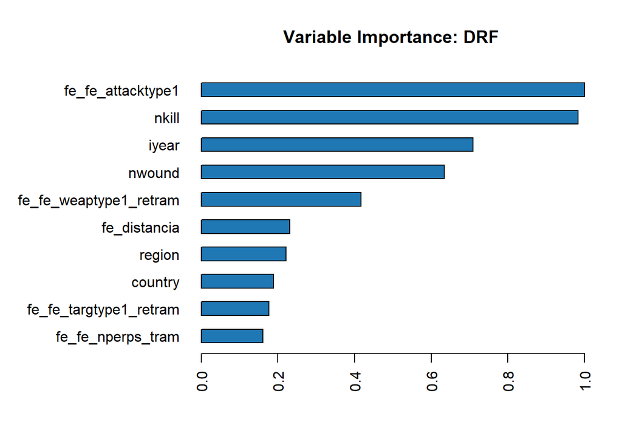

```r
h2o.varimp_plot(modelo16_rf_grid_es1)
```

### 5.4.4 Algoritmo ‘Random Forest’ con grid-research para el escenario 2

A continuación, utilizaré el mismo algoritmo anterior pero para los datos del escenario 2.

```r
#Fijo la semilla
set.seed(7)
modelo17_rf_grid_es2 <- h2o.randomForest(
  x = x_es2,
  y = y_es2,
  training_frame = train_es2_hex,
  validation_frame = valid_es2_hex,
  nfolds = 5, #Número de campos para la validación cruzada.
  keep_cross_validation_predictions = TRUE,
  keep_cross_validation_fold_assignment = TRUE,
  score_each_iteration = TRUE,
  score_tree_interval = 5, #Número de árboles tras los que se evalúa el modelo.
  fold_assignment = 'Modulo', #Forma determinista simple de dividir uniformemente el conjunto de datos.
  balance_classes = TRUE, #La variable objetivo no está balanceada por lo tanto balanceamos las clases.
  ntrees = 100, #Número de árboles
  max_depth = 10, #Profundidad máxima de los árboles(número de nodos)
  #Evitamos sobre ajuste
  stopping_tolerance = 0.01, #Porcentaje mínimo de mejora entre dos mediciones consecutivas
  stopping_rounds=3, #Número de mediciones consecutivas en las que no se debe superar el stopping_tolerance.
  stopping_metric="AUCPR",
  distribution = 'bernoulli',
  sample_rate = 0.74,#Porcentaje de observaciones aleatorias empleadas para el ajuste de cada árbol
  col_sample_rate_per_tree = 0.84,
  col_sample_rate_change_per_level = 1.02,
  min_split_improvement = 1e-4,
  seed = 7
)
```

- **Resultados del modelo.**

```r
#Imprimimos las métricas del modelo en Train
print(modelo17_rf_grid_es2)
```

```
## Model Details:
## ==============
##
## H2OBinomialModel: drf
## Model ID:  DRF_model_R_1632597003111_28789
## Model Summary:
##   number_of_trees number_of_internal_trees model_size_in_bytes min_depth
## 1               7                        7               63257        10
##   max_depth mean_depth min_leaves max_leaves mean_leaves
## 1        10   10.00000        653        803   716.57140
##
##
## H2OBinomialMetrics: drf
## ** Reported on training data. **
## ** Metrics reported on Out-Of-Bag training samples **
##
## MSE:  0.2421189
## RMSE:  0.4920558
## LogLoss:  0.7066771
## Mean Per-Class Error:  0.1839096
## AUC:  0.9011134
## AUCPR:  0.9076237
## Gini:  0.8022268
## R^2:  0.03152432
##
## Confusion Matrix (vertical: actual; across: predicted) for F1-optimal threshold:
##           No   Yes    Error           Rate
## No     70509 18795 0.210461   =18795/89304
## Yes    14048 75226 0.157358   =14048/89274
## Totals 84557 94021 0.183914  =32843/178578
##
## Maximum Metrics: Maximum metrics at their respective thresholds
##                         metric threshold        value idx
## 1                       max f1  0.853029     0.820819 104
## 2                       max f2  0.678768     0.876742 191
## 3                 max f0point5  0.926479     0.844616  60
## 4                 max accuracy  0.886074     0.821087  84
## 5                max precision  0.999952     0.999254   0
## 6                   max recall  0.000012     1.000000 399
## 7              max specificity  0.999952     0.999955   0
```

[output cut: 122 more lines]

```
## f1                        0.9547103   0.9551236 0.95446134
## f2                       0.97074896   0.9726386  0.9745147
## lift_top_group            1.1286745   1.1295614  1.1297278
## logloss                   0.2264235  0.22800365 0.22560462
## max_per_class_error      0.58199847  0.59590596  0.6372586
## mcc                      0.51972675  0.52199686   0.504348
## mean_per_class_accuracy  0.69987285   0.6943853 0.67554986
## mean_per_class_error     0.30012718   0.3056147  0.3244501
## mse                     0.067927554 0.068084784 0.06739403
## pr_auc                    0.9853962    0.984452  0.9849179
## precision                 0.9291254   0.9272929 0.92281234
## r2                       0.32750204   0.3295073 0.33696595
## recall                    0.9817441   0.9846766  0.9883584
## rmse                     0.26062915   0.2609306  0.2596036
## specificity              0.41800153    0.404094 0.36274138
```

Con este modelo obtenemos un porcentaje de **‘AUCPR’** del **90.76%** en los datos de train y un **98.63%** con los **datos** de **validación**.

Si observamos las métricas obtenidas en la fase de validación cruzada, podemos ver que el **nivel** de **predicción medio** es del **98.49%**, con una **desviación típica** del **0.0003**. Por lo que, el nivel de predicción se **mantiene** en un **98%**.

- **Evaluación del modelo**

Evaluamos el modelo teniendo en cuenta los datos de test.

```r
h2o.performance(modelo17_rf_grid_es2, newdata = test_es2_hex)
```

```
## H2OBinomialMetrics: drf
##
## MSE:  0.06888527
## RMSE:  0.26246
## LogLoss:  0.2299459
## Mean Per-Class Error:  0.3016852
## AUC:  0.9049636
## AUCPR:  0.9844101
## Gini:  0.8099272
## R^2:  0.3264255
##
## Confusion Matrix (vertical: actual; across: predicted) for F1-optimal threshold:
##          No   Yes    Error         Rate
## No     1830  2592 0.586160   =2592/4422
## Yes     582 33235 0.017210   =582/33817
## Totals 2412 35827 0.083004  =3174/38239
##
## Maximum Metrics: Maximum metrics at their respective thresholds
##                         metric threshold        value idx
## 1                       max f1  0.660267     0.954425 269
## 2                       max f2  0.505433     0.977386 323
## 3                 max f0point5  0.800493     0.948192 198
## 4                 max accuracy  0.695247     0.917336 252
## 5                max precision  0.999164     1.000000   0
## 6                   max recall  0.150945     1.000000 394
## 7              max specificity  0.999164     1.000000   0
## 8             max absolute_mcc  0.706795     0.544195 247
## 9   max min_per_class_accuracy  0.884662     0.823383 141
## 10 max mean_per_class_accuracy  0.899681     0.825682 130
## 11                     max tns  0.999164  4422.000000   0
## 12                     max fns  0.999164 33427.000000   0
## 13                     max fps  0.037761  4422.000000 399
## 14                     max tps  0.150945 33817.000000 394
## 15                     max tnr  0.999164     1.000000   0
## 16                     max fnr  0.999164     0.988467   0
## 17                     max fpr  0.037761     1.000000 399
## 18                     max tpr  0.150945     1.000000 394
##
## Gains/Lift Table: Extract with `h2o.gainsLift(<model>, <data>)` or `h2o.gainsLift(<model>, valid=<T/F>, xval=<T/F>)`
```

Vemos como la precisión del modelo se sitúa en los **datos** de **test** en un **98.44%** (porcentaje parecido a los obtenidos en test y validación), lo que indica que el modelo generaliza bien.

- **Matriz de confusión.**

```r
#Obtengo la matriz de confusión en test
h2o.confusionMatrix(modelo17_rf_grid_es2, newdata = test_es2_hex, metric = 'accuracy')
```

```
## Confusion Matrix (vertical: actual; across: predicted)  for max accuracy @ threshold = 0.695246506170119:
##          No   Yes    Error         Rate
## No     2141  2281 0.515830   =2281/4422
## Yes     880 32937 0.026022   =880/33817
## Totals 3021 35218 0.082664  =3161/38239
```

Si observamos la matriz de confusión, podemos ver que de los 3021 atentados que en realidad no son exitosos, el modelo ha sido capaz de reconocer a 2141 (hay 880 falsos positivos), de 35218 que son en realidad atentados exitosos, el modelo reconoce a 32937 (hay 2281 falsos negativos).

Es decir, tenemos una **capacidad de reconocer** los **atentados exitosos** del **93.52%** (Recall-‘Yes’: Sensibildad) y una capacidad de clasificar lo atentados **no exitosos** del **70.87%** (Recall - ’No: Especifidad). Un porcentaje **bueno**.

Esto se ve reflejado en la **capacidad media** de reconocer los casos correctamente , **tanto exitosos** como **no exitosos**, es del **82.19%** (Balanced Accuracy: Media de los ‘Recall’ en las dos clases).

- **Importancia de cada variable.**

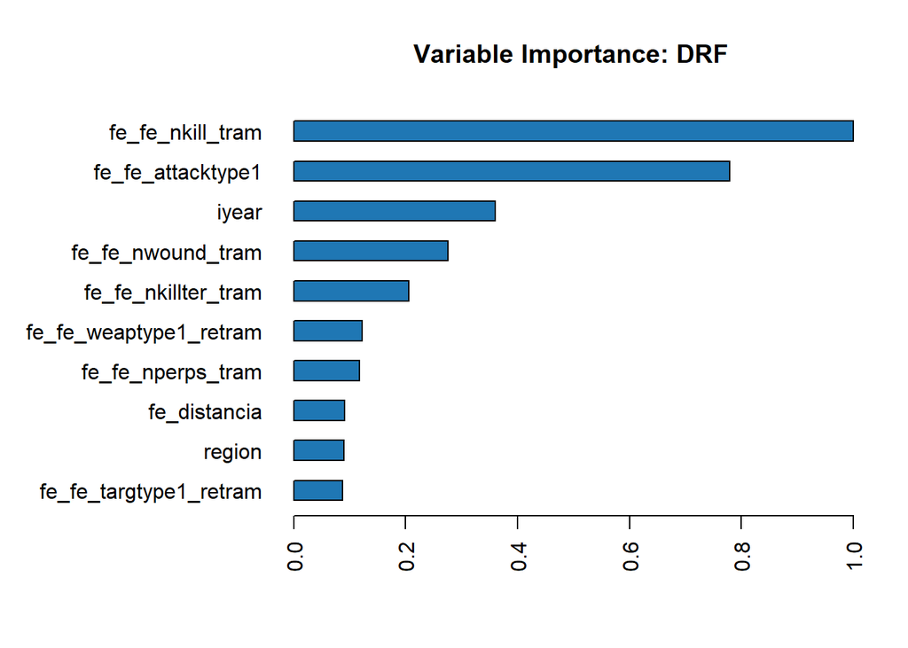

```r
h2o.varimp_plot(modelo17_rf_grid_es2)
```

Las variables más importantes para este modelo son: **‘nkill’**, **‘attacktype1’**, **‘iyear’** y **‘nwound’**.

# 6 Elección del modelo ganador

Dado que **todos** los modelos generados, tienen una **alta** **capacidad** de **predicción y precisión**, a la hora de **clasificar** los casos de **atentados exitosos**, seleccionaré el **mejor modelo**, entre aquellos cuya capacidad de **clasificar** los **casos no exitosos**, (’Recall: No éxitosos) sea **más alta**.

Así pues, **descarto** los modelos generados por algoritmos lineales como **‘GLM’ y ‘LDA’**, ya que, no daban buenos resultados de ‘Recall’, en este caso.

El algoritmo **‘Ranger’**, lo **descarto** ya que obteníamos un **‘Recall’** de **casos no exitosos** del 50.98%, un porcentaje **más bajo**, **que** en los modelos generados por **‘GBM’ y ‘Random Forest’**.

**Tampoco** cuento con el mejor modelo generado por el **algoritmo ‘automl’**, ya que, el mejor **modelo** de este algoritmo fué un **‘StackedEnsemble’**. Para este tipo de modelos, **no** es posible **obtener** las **variables más importantes**. Debido a esto, lo descarto, ya que el conocer las variables más influyentes del modelo, es fundamental y objetivo imprescindible para el enfoque de este trabajo y para el área de negocio.

Para elegir el modelo me basaré en la **métrica**, **AUCPR**, que el área bajo la **curva** que relaciona la **capacidad** (‘Recall’) y la **‘Precisión’**. Esta medida es útil cuando las clases estan desbalanceadas.

A continuación, incluyo los modelos candidatos en un gráfico.

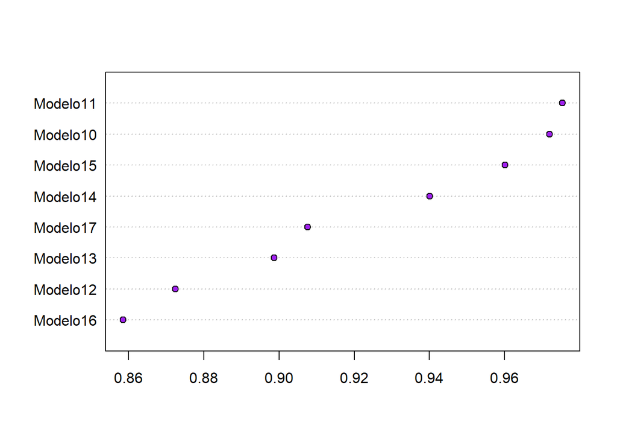

```r
#Computo las métricas de cada modelo
metrica_1 <- h2o.aucpr(modelo10_gbm_es1 )
metrica_2 <- h2o.aucpr(modelo11_gbm_es2)
metrica_3 <- h2o.aucpr(modelo12_gbm_grid_es1)
metrica_4 <- h2o.aucpr(modelo13_gbm_grid_es2)
metrica_5 <- h2o.aucpr(modelo14_rf_es1)
metrica_6 <- h2o.aucpr(modelo15_rf_es2)
metrica_7 <- h2o.aucpr(modelo16_rf_grid_es1)
metrica_8 <- h2o.aucpr(modelo17_rf_grid_es2)

aucpr <- c(metrica_1,metrica_2, metrica_3, metrica_4, metrica_5, metrica_6, metrica_7, metrica_8)
modelo <- c("Modelo10", "Modelo11", "Modelo12", "Modelo13", "Modelo14","Modelo15","Modelo16","Modelo17")
datos <- data.frame(modelo, aucpr)
#ordeno los datos por 'aucpr'
x <- datos[order(datos$aucpr), ]
#Gráfico de clasificación por 'aucpr'
dotchart(x$aucpr, labels = x$modelo, pch = 21, bg = "purple")
```

Gráficamente podemos ver que el **modelo** que tiene un **área mayor bajo la curva entre la ‘Precisión’ y el ‘Recall’** (Capacidad de clasificar correctamente), **es** el **modelo 11** ( modelo11_gbm_es2). Por lo tanto, ese será el mejor modelo predictivo en la clasificación de los atentados.

# 7 Conclusiones.

- Tras **limpiar** los **datos**, **entender** la **naturaleza** y **distribución** de las variables que componen el dataset, **y** realizar las **transformaciones** necesarias, tanto para el correcto funcionamiento de los algoritmos, como para la optimización de los resultados, **empecé generando algoritmos** clásicos de la libería caret, como **‘GLM’** y **‘LDA’**, y no tan clásicos, de la librería H2O, como **‘Automl’**, **‘GBM’**, **‘Radom Forest’** y **‘Ranger’** de la librería caret.
- Analicé el **resultado** de cada modelo, en **dos tipos de escenario**, **uno** con **variables originales** y **otro** con ciertas **variables tramificadas**, con el fin de optimizar el resultado del modelo.
- En todo momento **controlé** que **no** se produjera **overfitting**, mediante **técnicas de regularización**, como incluir en todos los algoritmos ,**‘cross validation’**, inlcuso **ajustando** los parámetros de **‘max_depth’**, **‘Mtry’** y **‘nodesize’**. Sobre todo en los algoritmos basados en áboles de decisión, que son más propensos al sobreajuste.
- Dada la **presencia** de **clases desbalanceadas** en el conjunto de datos, también traté esta problemática **en los algoritmos**, **especificando** la **presencia** de clases desbalanceadas en el dataset (‘balance_classes = TRUE’) **y optimizando** el **‘AUCPR’** en lugar del ‘Accuracy’, en aquellos agoritmos que permiten la utilización de métrica. No opté por modificar el dataset (utilizando Oversampling ó Upsampling), ya que, no suele dar buenos resultados, si incluímos filas podemos caer en overfitting, y si hacemos oversampling, podemos prescindir de muestras importantes que nos den información.
- Dado que los **modelos predictivos**, tienden a **centrar** su **atención** sobre los casos de la **clase mayoritaria**, éstos **no** han tenido **problemas** en **clasificar** los **atentados exitosos**, asi pues, **he intentado** en todo momento **optimizar** tanto la **capacidad** de clasificación y **precisión** de la **clase minoritaria**, esto es, el que un **atentado** sea **no exitoso**.
- Para cada algoritmo, tanto ‘GBM’ como ‘Ranger’ó ’Random Forest’, **utilicé** un **grid-research** para poder afinar un poco más los parámetros utilizados, con la intención de ir mejorando la capacidad predictiva de los modelos generados. Aún así es **posible**, que con otro tipo de **algoritmos más potentes** se pueda conseguir una **mejor predicción**.
- **Elección del mejor modelo predictivo**
  - A la hora de **elegir** el mejor **modelo**, he tenido en **cuenta dos características** del modelo clasificador, tanto el **nivel** de **capacidad** en **clasificar** **correctamente** los casos negativos, es decir, los **casos no exitosos**, como la **precisión** alcanzada. Es decir, aquel **modelo** cuyo nivel de **‘AUCPR’** sea **mayor**, será el mejor modelo. Siendo el ‘AUCPR’, el área bajo la **curva** que **relaciona** la **capacidad** (‘Recall’) y la **‘Precisión’**.
  - Entre los **posibles** modelos **ganadores**, están aquellos cuya puntuación de **‘Recall’** en los **casos negativos** es **mayor** del **70%** (Nivel aceptable de capacidad).
  - A continuación, muestro un **resumen** de las métricas obtenidas en aquellos **modelos** cuya capacidad de clasificar los casos no exitosos ha sido, por encima del 70% (**‘Recall_no’ > 70%**).

```r
#Introduzco las medidas de todos los modelos
Recall_yes <-c(88.70, 89, 88.68, 88.95, 97.51, 97.41, 99.98, 99.89, 94.35, 97.19, 93.60, 90.53, 90.59, 92.66, 93.23, 92.07, 93.52)

Precision_yes <- c(99.83, 99.72, 99.9, 99.84, 93.97, 93.97, 88.86, 89.41, 97.70, 98.26, 97.70, 99.39, 97.37, 98.45, 98, 98, 97.39)

Recall_no <- c(18.31, 61.38, 0.0, 69.71, 50.98, 50.98, 1, 7, 75.90, 77.73, 75.32, 81.71, 81.62, 77.37, 75.73, 69.87, 70.87)

Precision_no <- c(0.3, 3, 0.0, 2, 72.31, 71.49, 92.94, 89.85, 55.26, 46.26, 48.86,20.51, 21, 40.36, 45.59, 35.45, 48.41 )

#Creo la variable con los nombres de todos los modelos
modelos <- c('Modelo1_glm_es1', 'Modelo2_glm_es2', 'Modelo3_lda_es1', 'Modelo4_lda_es2','Modelo5_ranger_es1', 'Modelo6_ranger_es2', 'Modelo7_ranger_grid_es1','Modelo8_ranger_grid_es2', 'Modelo9_automl_es2', 'Modelo10_gbm_es1', 'Modelo11_gbm_es2', 'Modelo12_gbm_grid_es1', 'Modelo13_gbm_grid_es2', 'Modelo14_rf_es1', 'Modelo15_rf_es2', 'Modelo16_rf_grid_es1', 'Modelo17_rf_grid_es2')

#Creo el data frame con todas las métricas
metricas <- data.frame(modelos, Recall_yes, Precision_yes, Recall_no, Precision_no)

#Ordeno el data frame según la Precisión de los casos no exitosos
metricas_ordenado <- metricas[order(metricas$Precision_no,decreasing = TRUE) , ]

#Muestro aquello cuya capacidad de precisión sea mayor de 70%
modelos_final <- metricas_ordenado %>%
    filter(Recall_no > 70) %>%
    select(modelos,Recall_yes, Precision_yes, Recall_no, Precision_no)
modelos_final
```

```
##                 modelos Recall_yes Precision_yes Recall_no Precision_no
## 1    Modelo9_automl_es2      94.35         97.70     75.90        55.26
## 2      Modelo11_gbm_es2      93.60         97.70     75.32        48.86
## 3  Modelo17_rf_grid_es2      93.52         97.39     70.87        48.41
## 4      Modelo10_gbm_es1      97.19         98.26     77.73        46.26
## 5       Modelo15_rf_es2      93.23         98.00     75.73        45.59
## 6       Modelo14_rf_es1      92.66         98.45     77.37        40.36
## 7 Modelo13_gbm_grid_es2      90.59         97.37     81.62        21.00
## 8 Modelo12_gbm_grid_es1      90.53         99.39     81.71        20.51
```

- Como podemos ver en esta tabla, el modelo con mayor nivel de ‘Precisión’ en los casos negativos, es el **‘Modelo9_automl_es2’**, este modelo fué generado por el algoritmo ‘automl’, y **es** un **conjunto de modelos ensamblados**. Lo que significa que **no** se puede **conocer** la **importancia** que tienen las **variables predictoras** para el modelo de clasificación. Dado que una de las premisisas del estudio y del área de negocio es conocer, cuáles son los principales factores que influyen a la hora de clasificar los atentados, **no** me **quedaré** con **este modelo**.
- Por lo tanto, el **siguiente modelo** que **alcanza** una **mayor precisión** en los **casos negativos** es el **‘Modelo11_gbm_es2’**, convirtiéndose así en el **mejor modelo** para predecir **si** un **atentado** se llevará a cabo con **éxito o fracaso**.
- **Caráterísticas del mejor modelo predictivo: Explicatividad del modelo**
  - Con el **fin** de alcanzar una **mayor optimización** en el ajuste del modelo, este modelo se **entrenó** con los **datos** del **escenario 2**, es decir, dataset con las **variables** numéricas: ‘nkill’, ‘nkillter’, ‘nwound’, ‘nwoundte’, ‘npercap’, ‘iday’ e ‘imonth’, **recategorizadas**. Éste objetivo se cumplió, ya que se alcanzó un mayor nivel de predicción respecto a los alcanzados con los datos del escenario 1.
  - El modelo alcanzó un **nivel de precisión y capacidad de clasificación** en **train**, del **97.51%**, un nivel de **predicción medio** del **98.58%** en la fase de **‘Cross Validation’** y porcentaje de precisión y capacidad del **98.28%**, en **test**. Un **porcentaje de clasificación bastante elevado**, teniendo en cuenta que la **mayor aportación** a este porcentaje es debido a la **correcta predicción** de los **atentados exitosos**.

```r
#matriz de confusión del modelo, en test
h2o.confusionMatrix(modelo11_gbm_es2, newdata = test_es2_hex, metric = 'accuracy')
```

```
## Confusion Matrix (vertical: actual; across: predicted)  for max accuracy @ threshold = 0.885967938481439:
##          No   Yes    Error         Rate
## No     2161  2261 0.511307   =2261/4422
## Yes     708 33109 0.020936   =708/33817
## Totals 2869 35370 0.077643  =2969/38239
```

- Si observamos la matriz de confusión, podemos ver que de los 2869 atentados que en realidad no son exitosos, el modelo ha sido capaz de reconocer a 2161 (hay 708 falsos positivos), de 35370 que son en realidad atentados exitosos, el modelo reconoce a 33109 (hay 2261 falsos negativos).
- Es decir, tenemos una **capacidad de reconocer** los **atentados exitosos** del **93.60%** (Recall-‘Yes’: Sensibildad) y una capacidad de clasificar lo atentados **no exitosos** del **75.32%** (Recall - ’No: Especifidad). Un porcentaje **bastante bueno**.
- Esto se ve reflejado en la **capacidad media** de reconocer los casos correctamente , **tanto exitosos** como **no exitosos**, es del **84.46%** (Balanced Accuracy: Media de los ‘Recall’ en las dos clases).
- En cuanto a la **‘Precisión’** del modelo, es decir, cuanto de confiable es el modelo en clasificar correctamente, tenemos que en los **casos exitosos**, el modelo tiene una precisión del **97.90%**. **Y** el nivel de precisión en los casos **no exitosos**, es del **48.86%**. No es un porcentaje muy alto, aunque sí es el **mayor** que hemos alcandado, dentro de los modelos potencialmente válidos.
- **Importancia de cada variable.**

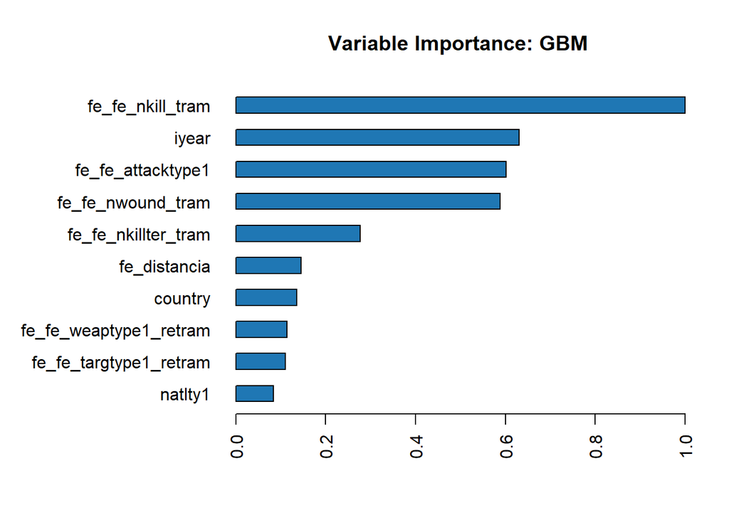

```r
h2o.varimp_plot(modelo11_gbm_es2)
```

- Podemos ver que, las **variables más importantes** a la hora de clasificar los atentados, por encima del 50% de **son**: el **número de muertos** (‘nkill_tram’), **el año del atentado** (‘iyear’), **el tipo de ataque** (‘attacktype1’) **y** el **número de heridos** (‘nwound_tram’). Siendo el **número de muertos**, la variable **la más influyente**, para la clasificación con diferencia respecto al resto.
- Debido a que este modelo tiene un buen nivel de predicción, podemos llevarlo a producción, es decir, pasarle al modelo nuevos valores y que éste nos devuelva una predicción, en nuestro caso, que nos clasifique el atentado en exitoso o no.

```r
#Guardo el modelo y los datos de train, validación y test utilizados
h2o.saveModel(modelo11_gbm_es2, path = "modelo11_gbm_es2_001")
```

```
## [1] "C:\\Users\\Marian Mira\\Desktop\\Formacion mi Pc\\MASTER - BD Y DATA SCIENCE\\TFM\\modelo11_gbm_es2_001\\GBM_model_R_1632597003111_1411"
```

```r
h2o.save_frame(train_es2_hex, dir = "train_es2_hex")
h2o.save_frame(test_es2_hex, dir = "test_es2_hex")
h2o.save_frame(valid_es2_hex, dir = "valid_es2_hex")
#Cierro el cluster H2o.
h2o.shutdown( prompt = FALSE)
```